# Kostenoffenlegung als Wettbewerbsvorteil

Chancen und Potenziale der Kostentransparenz

# Motivation

Die Untersuchung von Kostentransparenz ist aus ökonomischer Sicht besonders spannend, da sie Einblicke in das Zusammenspiel von Marktverhalten, Preiswahrnehmung und Konsumentenvertrauen ermöglicht. In klassischen Märkten gilt Information als asymmetrisch verteilt - insbesondere Kostenstrukturen bleiben für Konsument:innen meist verborgen. Wenn Unternehmen jedoch freiwillig ihre Produktionskosten offenlegen, entsteht eine neue Form der Marktkommunikation, die sowohl auf das Kaufverhalten als auch auf die Markenbindung Einfluss nehmen kann.

In diesem Projekt beschäftigen Sie sich mit der ökonomischen Wirkung unterschiedlicher Formen von Kostentransparenz, darunter produktbezogene Einzelkosten-Offenlegung im Point-of-Sale oder auch verbal vermittelte Transparenz in Kombination mit Vertrauensmessung. Ziel ist es, zu untersuchen, wie sich diese Varianten auf Zahlungsbereitschaft, Vertrauen und wahrgenommene Preisfairness auswirken.

Kern dieser Ausarbeitung ist die Frage, inwiefern Kostentransparenz eine rationale Kaufentscheidung unterstützt oder über emotionale Mechanismen - etwa durch erhöhte Markenattraktivität - wirkt. Für die Analyse greifen Sie auf ein breites Methodenrepertoire zurück, das ökonomische Modellierung mit experimenteller Verhaltensforschung verbindet, und leisten so einen Beitrag zum besseren Verständnis moderner Konsumentenentscheidungen in transparenten Märkten. Für ihre Analyse verwenden Sie die Daten der folgenden Ausarbeitung:

**Mohan, B., Buell, R. W., & John, L. K. (2020). Lifting the veil: The benefits of cost transparency. Marketing Science, 39(6), 1105-1121.**

# Aufbau der Studie

1. Lesen Sie sich den folgenden Text zum Hintergrund und Aufbau der Studie durch und beantworten Sie nachfolgende Fragen dazu:

Der Ausgangspunkt der betrachteten Untersuchung war ein reales Ereignis: Ein Online-Händler stellte im Dezember 2013 ein hochwertiges Lederportemonnaie zum Verkauf. Einige Wochen später wurde auf den Produktseiten eine Infografik zur Kostenzusammensetzung ergänzt, allerdings versehentlich nur bei drei von fünf Farbvarianten. Obwohl der Händler diesen Fehler nicht beabsichtigte, entstand daraus ein sogenanntes natürliches Experiment, also eine reale Vergleichssituation mit kontrollierbaren Unterschieden. Die Verkäufe konnten analysiert werden, um zu überprüfen, ob die Offenlegung der Produktionskosten einen Einfluss auf das Kaufverhalten hatte.

Dieses natürliche Experiment lieferte erste Hinweise darauf, dass Kostentransparenz wirkt - und war damit die Basis für zwei gezielte Experimente im Labor, die Sie sich in diesem Projekt genauer anschauen sollen. Beide Laborexperimente knüpfen an die reale Ausgangslage an - gehen aber unterschiedliche Forschungsfragen an:

Experiment 1: In einem realitätsnahen Online-Setting wurde untersucht, ob Konsument:innen anders entscheiden, wenn sie Informationen zu Produktionskosten sehen. Hierbei sahen die Teilnehmer:innen eine Produktseite für einen Rucksack von Everlane - entweder mit oder ohne Kostenaufstellung (vgl. Abbildung 1: Kostentransparenz Infografik im Anhang). Zusätzlich wurde ein Vergleichsprodukt von J. Crew gezeigt (ohne Hinweise zur Kostenzusammensetzung). Die Teilnehmer:innen mussten entscheiden, von welchem Anbieter sie lieber einen Gutschein erhalten würden. Das Ziel der Forscher war es zu messen, ob Konsument:innen bei mehr Transparenz auch eher kaufen, folglich sich für diesen Gutschein entscheiden.

Experiment 2: Nachdem Experiment 1 zeigte, dass es einen Effekt der Kostentransparenz gibt, stellt sich die psychologische Anschlussfrage, warum es diesen Effekt gibt und wie dieser festzumachen ist. So sahen die Teilnehmer:innen im 2. Experiment ein fiktives Produkt - eine Schokoladentafel. In der Kontrollgruppe wurden nur übliche Produktinfos gezeigt. In der Treatmentgruppe gab es zusätzlich eine detaillierte Kostenaufstellung (vgl. Abbildung 2: Design der Schokoladenverpackung ohne und mit Kostentransparenz im Anhang). Im Anschluss wurden Vertrauen in die Marke und Kaufbereitschaft durch einen Fragebogen abgefragt. So sollte herausgefunden werden, ob Vertrauen der zentrale psychologische Mechanismus für die Kaufentscheidung der Kund:innen ist.

Beantworten Sie nun folgende Fragen:

1. Welches reale Ereignis war der Auslöser der Forschung?
2. Welche konkrete Verhaltensfrage steht im Mittelpunkt von Experiment 1 - Was wollten die Forscher:innen direkt am Kaufverhalten testen?
3. Welcher psychologische Faktor steht im Zentrum von Experiment 2 - und wie hängt er mit dem Kaufverhalten zusammen?

**a) Welches reale Ereignis war der Auslöser der Forschung?**  
Der Auslöser der Forschung war ein reales Ereignis im Dezember 2013, als ein Online-Händler ein hochwertiges Lederportemonnaie zum Verkauf stellte. Einige Wochen später ergänzte der Händler versehentlich nur bei drei von fünf Farbvarianten eine Infografik zur Kostenzusammensetzung auf den Produktseiten. Dieses unbeabsichtigte Vorgehen führte zu einem sogenannten natürlichen Experiment.

**b) Welche konkrete Verhaltensfrage steht im Mittelpunkt von Experiment 1 – Was wollten die Forscher:innen direkt am Kaufverhalten testen?**  
Im Mittelpunkt von **Experiment 1** stand die Frage, **ob Konsument:innen anders entscheiden**, wenn sie Informationen zu Produktionskosten sehen. Die Forscher:innen wollten **messen, ob Konsument:innen bei mehr Transparenz eher kaufen**, also ob sie sich eher für den Gutschein des Anbieters mit Kostentransparenz entscheiden.

**c) Welcher psychologische Faktor steht im Zentrum von Experiment 2 – und wie hängt er mit dem Kaufverhalten zusammen?**  
Im Zentrum von **Experiment 2** steht der psychologische Faktor **Vertrauen in die Marke**. Das Experiment untersuchte, ob Vertrauen **der zentrale psychologische Mechanismus** für die Kaufentscheidung der Kund:innen ist – also ob **Kostentransparenz das Vertrauen stärkt** und dadurch **die Kaufbereitschaft erhöht**.

Nachdem Sie nun die grundlegende Forschungsidee und Zielsetzung der beiden Experimente kennengelernt haben, befassen wir uns im nächsten Schritt vertiefend mit Experiment 1. Ziel ist es, den genauen Aufbau, sowie das konkrete Verhalten der Teilnehmer:innen besser zu verstehen.

2. Lesen Sie sich den folgenden Text zum Aufbau des ersten Experiments durch und beantworten Sie anschließend Fragen dazu:

Cost transparency refers to the disclosure of the costs to produce a good or provide a service. Although cost transparency is a strategy traditionally employed in the context of supplier-firm relationships, wherein the two-way sharing of cost information between parties facilitates collaboration on cost reduction measures, we investigate its effects within the context of consumer-firm relationships. Information on the costs associated with providing goods and services is rarely shared with consumers, but we provide evidence of when and why voluntarily doing so can increase consumers’ purchase interest. Specifically, building on the psychology of disclosure and trust, we posit that cost transparency, insofar as it represents an act of intimate disclosure, fosters trust. In turn, we propose that this heightened trust increases consumers’ willingness to purchase from the transparent firm. In the sections that follow, we discuss our central predictions and highlight alternative accounts. Then, we present experiments, conducted in the lab and in the field, that document the main effects of cost transparency, its underlying psychological drivers, and conditions that moderate its effects.

This first experiment explores how cost transparency influences consumer preferences in an online shopping context. The study was designed as a between-subjects randomized experiment using an incentive-compatible setup, meaning participants made real choices with the possibility of receiving a tangible reward. A total of 509 U.S.-based participants were recruited through Amazon Mechanical Turk (MTurk). Each participant was randomly assigned to one of two experimental conditions:

- Cost Transparency Condition: Participants were shown a simulated product page for a backpack sold by the retailer Everlane. This page included a cost breakdown infographic, listing the production costs such as materials, labor, transport, and duties, with a clearly stated total cost.
- Control Condition: Participants saw the same backpack from Everlane but without any cost information. In both conditions, participants also saw a comparable backpack from J. Crew, which does not practice cost transparency.

Participants were instructed to view both product pages and then asked which company they would prefer to receive a $50 gift card from. Their response served as the main behavioral outcome, representing a choice between the transparent vs. non-transparent retailer. To ensure accurate interpretation of the presented information, a comprehension check followed the main choice question. Participants were also asked for demographic information such as age, gender, income, and education, to allow for potential control variables in later analysis.

Beantworten Sie nun folgende Fragen:

1. Wie viele Personen nahmen final an dem Experiment teil?
2. Worin bestand der Unterschied zwischen der Transparenzbedingung und der Kontrollbedingung?
3. Welche Anreizstruktur wurde verwendet, um die Entscheidung der Teilnehmenden realistisch zu gestalten?
4. Wie unterschieden sich die beiden gezeigten Onlinehändler im Experiment?
5. Warum wurde im Anschluss an die Entscheidungsfrage ein Verständnischeck durchgeführt?
6. In der Beschreibung des Experiments wird von “between-subjects randomized experiment using an incentive-compatible setup” gesprochen. Was versteht man hierunter im Detail?

*Hinweis:* Für die Beantwortung der letzten Frage können Sie [diesen Artikel (Seite 1-5)](https://www.researchgate.net/publication/268269783_Incentives_in_Experiments_A_Theoretical_Analysis) als Grundlage verwenden.

**a) Wie viele Personen nahmen final an dem Experiment teil?**  
An dem Experiment nahmen insgesamt 509 Personen teil. Diese wurden über Amazon Mechanical Turk (MTurk) rekrutiert.

**b) Worin bestand der Unterschied zwischen der Transparenzbedingung und der Kontrollbedingung?**  
In der Transparenzbedingung wurde den Teilnehmer:innen eine Produktseite für einen Rucksack des Anbieters Everlane gezeigt, die eine detaillierte Infografik mit der Kostenaufstellung enthielt (z.B. Material-, Arbeits-, Transportkosten und Zölle). In der Kontrollbedingung wurde derselbe Rucksack gezeigt, jedoch ohne jegliche Informationen zu den Produktionskosten.

**c) Welche Anreizstruktur wurde verwendet, um die Entscheidung der Teilnehmenden realistisch zu gestalten?**  
Es wurde ein sogenanntes „incentive-compatible setup“ verwendet. Das bedeutet, dass die Teilnehmer:innen eine reale Entscheidung trafen – nämlich die Wahl zwischen zwei Anbietern im Hinblick auf einen $50-Gutschein, den sie tatsächlich erhalten konnten. Dies sollte sicherstellen, dass die Entscheidung authentisch und mit echtem Anreiz getroffen wurde.

**d) Wie unterschieden sich die beiden gezeigten Onlinehändler im Experiment?**  
Der Unterschied bestand darin, dass Everlane in einer Bedingung Kostentransparenz praktizierte, indem eine Infografik mit Produktionskosten eingeblendet wurde. J. Crew hingegen wurde in beiden Bedingungen ohne jegliche Kostenaufstellung präsentiert – also ohne Kostentransparenz.

**e) Warum wurde im Anschluss an die Entscheidungsfrage ein Verständnischeck durchgeführt?**  
Ein Verständnischeck wurde eingebaut, um sicherzustellen, dass die Teilnehmenden die gezeigten Informationen korrekt interpretiert und verstanden haben. Nur so können die Antworten im Experiment als valide betrachtet werden.

**f) In der Beschreibung des Experiments wird von “between-subjects randomized experiment using an incentive-compatible setup” gesprochen. Was versteht man hierunter im Detail?**  
Ein „between-subjects randomized experiment“ bedeutet, dass jede Versuchsperson zufällig nur einer der beiden Bedingungen zugewiesen wurde – entweder der Transparenz- oder der Kontrollbedingung. Es handelt sich also um einen Vergleich zwischen verschiedenen Gruppen, nicht innerhalb derselben Person. Das „incentive-compatible setup“ beschreibt eine Versuchsanordnung, bei der die Entscheidung der Teilnehmenden echte Konsequenzen hat – in diesem Fall die reale Möglichkeit, einen 50-Dollar-Gutschein zu gewinnen. Dies erhöht die ökologische Validität des Experiments, da sich die Teilnehmer:innen realistischer verhalten. Diese Anreizstruktur wird in der Verhaltensforschung empfohlen, um verzerrte Ergebnisse durch hypothetische Entscheidungen zu vermeiden (vgl. Hertwig & Ortmann, 2001: Incentives in Experiments).

# Daten

## Datenimport und -aufbereitung

Die Daten, die Sie für die nachfolgenden Analysen verwenden, wurden zu Replikationszwecken von den Autoren der Studie zur Verfügung gestellt und können hier heruntergeladen werden:

**Bhavya Mohan, Ryan W. Buell, Leslie K. John (2020) Lifting the Veil: The Benefits of Cost Transparency. Marketing Science 39(6):1105-1121. mksc.2019.1200.sm1.pdf**

Wir haben die Daten für Sie heruntergeladen und im Unterordner mit dem Namen `Daten` bereitgestellt. Für ihre Analyse werden die Dateien `Experiment1.csv` und `Experiment2.csv` genutzt. Für die Zusatzaufgabe ist die Datei `Experiment3.csv` relevant.

3. Lesen Sie den Datensatz `Experiment1.csv` aus dem Unterordner `Daten` in R ein. Nennen Sie den Datensatz in R `daten_exp1`.

Im Datensatz sind unterschiedliche Variablen enthalten. Weiterhin habe wir Ihnen ein Readme mit den Beschreibungen zu den Variablen bereitgestellt. Nutzen Sie dieses und den Text aus Aufgabe 2, um die Variablen zu beschreiben.

Zunächst wurden die Daten aus der Datei `Experiment1.csv` in R eingelesen und in dem Objekt `daten_exp1` gespeichert. Der Datensatz enthält Informationen von insgesamt 509 Teilnehmer:innen, die im Rahmen des ersten Experiments zur Wirkung von Kostentransparenz auf das Konsumentenverhalten befragt wurden. Die Daten umfassen acht Variablen, die sich wie folgt beschreiben lassen:

Die Variable `treatment` gibt an, ob eine Person der Kosten-Transparenz-Bedingung zugeordnet war (Wert = 1) oder zur Kontrollgruppe gehörte (Wert = 0). In der Transparenzbedingung sahen die Teilnehmenden eine Produktseite mit einer Infografik zur Kostenaufstellung, während diese Information in der Kontrollbedingung fehlte.

Die Variable `everlane` gibt die Entscheidung der Teilnehmenden an, ob sie sich für eine Geschenkkarte von Everlane (Wert = 1) oder von J. Crew (Wert = 0) entschieden haben. Dies stellt die zentrale abhängige Variable dar, die das Kaufverhalten widerspiegelt.

Die Variable `passed` dokumentiert, ob eine Person den anschließenden Verständnischeck bestanden hat (Wert = 1) oder nicht (Wert = 0). Dieser Check wurde verwendet, um sicherzustellen, dass die gezeigten Informationen korrekt verstanden wurden.

Mit der Variable `email_provided` wurde erfasst, ob die Teilnehmenden am Ende des Experiments eine E-Mail-Adresse angegeben haben, um die versprochene Geschenkkarte zu erhalten (1 = E-Mail angegeben, 0 = keine Angabe). Dies kann auch als Maß für die Ernsthaftigkeit der Teilnahme interpretiert werden.

Die Variable `female` gibt das Geschlecht der Befragten an, wobei 1 für weiblich und 0 für männlich steht. Die Angabe war freiwillig.

Die Variable `age` enthält die offen abgefragten Altersangaben der Teilnehmenden in numerischer Form.

Die Variable `educ` beschreibt den höchsten erreichten Bildungsabschluss. Die Skala reicht von 1 (einige Jahre Schule) über 2 (Schulabschluss), 3 (einige Jahre College), 4 (Hochschulabschluss) bis 5 (postgraduale oder berufliche Ausbildung).

Schließlich beschreibt die Variable `income` das monatliche Einkommen der Teilnehmenden in zwölf gestuften Kategorien – von keinem Einkommen (1), über verschiedene Einkommensbereiche, bis hin zu über 10.000 Dollar (11) oder keine Angabe (12).

Diese Variablen bilden die Grundlage für die Analyse der Wirkung von Kostentransparenz auf das Verhalten der Konsument:innen.

## Deskriptive Analyse

Sie sollten sich im ersten Schritt einen Überblick über ihre Daten verschaffen.

4. Auf Basis des Datensatzes `daten_exp1` aus Aufgabe 3 erstellen Sie eine deskriptive Tabelle mit der Anzahl an Beobachtungen, den Mittelwerten, der Standardabweichungen, dem Median, sowie den Minima und Maxima für alle in `daten_exp1` enthaltenen Variablen.

Beschreiben und interpretieren Sie ihre Tabelle. Gehen Sie insbesondere auf die Verteilungen der einzelnen Variablen ein. Was fällt hier besonders auf.

Deskriptive Statistik

| Variable | N | Mittelwert | SD | Median | Minimum | Maximum |
| --- | --- | --- | --- | --- | --- | --- |
| Treatment | 509 | 0.50 | 0.50 | 0 | 0 | 1 |
| Everlane | 509 | 0.63 | 0.48 | 1 | 0 | 1 |
| Verständnischeck | 509 | 0.77 | 0.42 | 1 | 0 | 1 |
| E-Mail | 509 | 0.56 | 0.50 | 1 | 0 | 1 |
| Weiblich | 509 | 0.49 | 0.50 | 0 | 0 | 1 |
| Alter | 505 | 37.59 | 11.74 | 35 | 18 | 81 |
| Bildung | 505 | 3.76 | 0.84 | 4 | 1 | 5 |
| Einkommen | 505 | 7.58 | 2.43 | 8 | 1 | 12 |

**Beschreibung der Grafik**  
Die dargestellte Tabelle zeigt die deskriptive Statistik für unseren Datensatz. Dabei wird näher auf die Anzahl an Beobachtungen, den Mittelwert, den Median, die Standardabweichung, das Minimum und das Maximum eingegangen. Die Werte werden jeweils für jede Variable separat betrachtet.

**Interpretation der Grafik**  
Betrachtet man die Anzahl an Beobachtungen fällt auf, dass die Variablen Alter, Bildung und Einkommen jeweils nur 505 anstatt 509 Beobachtungen haben. Bei einer genaueren Betrachtung des Datensatzes fällt auf, dass vier Personen keine Angaben gemacht haben, was die Unterschiede erklären.  
Zusätzlich sollte man beachten, dass der Median, das Minimum und das Maximum nur bei den Variablen Alter, Bildung und Einkommen sinnvoll interpretiert werden kann, da die anderen Variablen sogenannte Dummyvariablen mit ausschließlich 0 und 1 Einträgen sind.

`Treatment:` Schaut man sich aber den Mittelwert der Variable Treatment an, liegt dieser bei 0,5, was auf eine gleichmäßige Verteilung der Treatment- und Kontrollgruppe hindeutet, also genau das, was man bei einem Experiment möchte.

`Everlane:` Der Mittelwert von Everlane liegt bei 0,63, was bedeutet, dass die Personen sich etwas öfters für die Geschenkkarte von Everlane entschieden haben. Da Everlane seine Kosten offengelegt hat, könnte hier eine erste Assoziation zwischen Kostentransparenz und Entscheidungsfindung festgestellt werden.

`Verständnischeck:` Der Mittelwert der Variable Verständischeck liegt bei 0,77, was bedeutet, dass 77% der Personen den Verständnischeck bestanden haben. Wir haben also relativ viele Personen, auf die wir zurückgreifen können.

`E-Mail:` Der Mittelwert der Variable E-Mail liegt bei 0,56. Das heißt, dass 56% der Personen ihre E-Mail Adresse angegeben haben um eine mögliche Geschenkkarte zu erhalten. Dieser Wert ist relativ gering, was darauf hindeuten könnte, dass manche Personen das Experiment nicht ganz ernst genommen haben oder weniger motiviert waren.

`Weiblich:` Der Mittelwert der Variable Weiblich liegt bei 0,49. Es gibt also fast gleich viele Frauen in dem Experiment wie Männer, was auf eine gute zufällige Verteilung hindeutet.

`Alter:` Der Mittelwert der Variable Alter ist bei 37,6. Die meisten Teilnehmer des Experiments sind also um die 37 Jahre alt. Da der Median bei 35 liegt kann man davon ausgehen, dass es vereinzelnte Ausreißer nach oben gibt, was den Mittelwert leicht verzerrt. Wenn man sich das Maximum anschaut, liegt dies bei 81. Die älteste Person ist also 81 Jahre alt, die junste hingegen 18 Jahre alt (Minimum).

`Bildung:` Der Mittelwert der Variable Bildung liegt bei 3,76. Da hier Werte zwischen eins bis fünf angenommen werden können haben die Teilnehmer im Durchschnitt einen eher höheren Bildungsstand. An Maximum und Minimum können wir aber sehen, dass die komplette Bandbreite dabei ist.

`Einkommen:` Der Mittelwert der Variable Einkommen liegt bei 7,58. Bei einer Skala von eins bis zwölf verdienen hier die meisten Personen also etwas über dem Durchschnitt. Auch hier gibt es Personen die sehr wenig verdienen und Personen die über 10000 Dollar verdienen. Hier sollte aber auch darauf geachtet werden, wie viele Personen keine Angabe zu ihrem Einkommen gemacht haben. Es könnte nämlich sein, dass Personen mit geringerem Einkommen keine Angaben gemacht haben und so die Statistik verzerrt ist.

5. Im Datensatz `daten_exp1` gibt es Variablen für die keine Beobachtungen vorhanden sind.
- Gegeben ihrer Variablenbeschreibung in Aufgabe 3:
  - Macht es Sinn die Beobachtungen aus dem Datensatz zu entfernen, wenn für bestimmte Variablen keine Werte vorhanden sind?
  - Wenn ja, warum?
  - Wie viele Beobachtungen entfernen Sie dadurch aus ihrem Datensatz?

Entfernen Sie nun alle Beobachtungen (d.h. gesamte Zeilen aus dem Datensatz), bei denen für mindestens eine der erhobenen Variablen kein Wert vorliegt, da unvollständige Daten für die Analyse nicht berücksichtigt werden sollen.

Untersuchen Sie weiterhin, ob sich die Teilnehmer, die die Webseite mit der Kostentransparenz gesehen haben (Treatmentgruppe), systematisch von jenen unterscheiden, die die Kontrollversion gesehen haben. Auch wenn es sich um ein Experiment handelt, bei dem die Zuteilung zu den Gruppen zufällig erfolgt ist, sollten Sie dennoch prüfen, ob es unbeabsichtigte (systematische) Unterschiede zwischen den Gruppen gibt. Erstellen Sie hierfür eine Balancing-Tabelle, in der Sie die Mittelwerte von Alter (age), Geschlecht (female), Einkommensstufe (income) und Bildungsniveau (educ) zwischen den beiden Gruppen vergleichen, die Differenzen berechnen und mithilfe von T-Tests prüfen, ob diese Unterschiede statistisch signifikant sind.

- Beschreiben und interpretieren Sie ihre Tabelle.
  - Was fällt Ihnen in Bezug auf die p-Werte auf?
  - Was müssten Sie bei einer weiteren Regressionsanalyse berücksichtigen?

*Hinweis:* Die beiden Gruppen, die Sie in der Balancing Tabelle betrachten sollen, können aus den Werten (1 und 0) der Variable `treatment` abgeleitet werden.

Balancing-Tabelle: Vergleich zwischen Treatment- und Kontrollgruppe

| Variable | Mittelwert Treatment | Mittelwert Kontrolle | Differenz | p-Wert |
| --- | --- | --- | --- | --- |
| Alter | 37.27 | 37.91 | -0.64 | 0.54 |
| Weiblich | 0.49 | 0.49 | 0.00 | 0.96 |
| Einkommen | 7.76 | 7.40 | 0.36 | 0.10 |
| Bildung | 3.79 | 3.73 | 0.06 | 0.42 |

**Macht es Sinn die Beobachtungen aus dem Datensatz zu entfernen, wenn für bestimmte Variablen keine Werte vorhanden sind?**  
Wenn die betroffenen Variablen, bei denen einzelne Werte nicht vorliegen relevant sind, sollten diese Beobachtungen entfernt werden. Denn meisten sind diese fehlenden Beobachtungen nicht zufäfflig, sondern haben einen bestimmten Grund (z.B. weil die Person keine Angaben machen wollte). Dadurch könnte unsere Analyse verzerrt werden, was unvorteilhaft wäre. Hier würden vier Beobachtungen entfernt werden, da für diese keine Daten vorliegen.

**Beschreibung der Grafik**  
In der Balancing-Tabelle wurden die Variablen Alter, Weiblich, Einkommen und Bildung auf einen signifikanten Unterschied zwischen den zwei Gruppen überprüft. Dabei wurde der Mittelwert der einzelnen Variablen jeweils aus der Treatment- und der Kontrollgruppe verglichen. Mithilfe des p-Werts lässt sich erkennen, ob die Differenz der Mittelwerte signifikant ist oder nicht.

**Interpretation der Grafik**  
Unsere Nullhypothese würde hier lauten, dass es einen signifikanten Unterschied zwischen Treatment- und Kontrollgruppe gibt. Da nicht gewollt ist, dass es einen signifikanten Unterschied gibt, ist hier das Ziel die Nullhypothese zu verwerfen. Eine Differenz gilt als signifikant, wenn sie auf dem 5% Niveau signifikant ist, d.h. ein p-Wert kleiner 0,05.  
Da alle p-Werte der Variablen größer als 0,05 sind, gibt es keinen signifikanten Unterschied zwischen Treatment- und Kontrollgruppe. Das deutet auf eine erfolgreiche Randomisierung des Experiments hin. Die Variable mit dem kleinsten p-Wert ist hier das Einkommen mit einem p-Wert von 0,1. Hier liegt also der größte Unterschied zwischen Treatment- und Kontrollgruppe vor, allerdings ist dieser Unterschied nicht signifikant. Die größte p-Wert liegt bei dem Geschlecht vor mit 0,96, was bedeutet, dass es hier nahezu keinen Unterschied zwischen den Gruppen gibt.  
Für eine weitere Regressionsanalyse scheinen also keine starken Verzerrungen zu erwarten sein. Allerdings liegt beim Einkommen ein gewisser Unterschied zwischen den Gruppen nahe, weshalb es Sinn machen könnte die Variable income als Kontrollvariable in das Modell aufzunehmen, um die Unterschiede zu kontrollieren.

Nachdem Sie sich in den vorangegangenen Aufgaben bereits mit der Verteilung der Daten und den Unterschieden zwischen den einzelnen Gruppen auseinandergesetzt haben, geht es nun um eine explorative Betrachtung von Zusammenhängen zwischen den zentralen Variablen im Datensatz.

6. In dieser Aufgabe führen Sie eine Korrelationsanalyse durch, um herauszufinden, ob und wie stark einzelne Merkmale - wie Alter, Bildung, Einkommen oder Geschlecht - mit der Treatment-Zugehörigkeit sowie der Entscheidung für die Everlane-Gutscheinkarte zusammenhängen.

Wählen Sie die folgenden Variablen aus dem Datensatz `daten_exp1` aus:

- treatment
- everlane
- age
- income
- educ
- female

Berechnen Sie die Korrelationsmatrix dieser Variablen. Visualisieren Sie die Matrix (als Tabelle oder Grafik), in der die Korrelationskoeffizienten und deren Stärke farblich dargestellt sind.

Beschreiben und interpretieren Sie ihre Tabelle/Grafik. Gehen Sie hierbei auch auf folgende Fragen ein:

- Was bedeutet ein positiver Zusammenhang (Korrelation) zwischen `treatment` und `everlane` im Kontext der Hypothese, dass Kostentransparenz die Entscheidung für Everlane beeinflusst?
- Warum kann eine Korrelation auf einen Zusammenhang hinweisen, aber nicht ausreichen, um einen kausalen Effekt nachzuweisen - selbst wenn wir wissen, dass `treatment` im Experiment zufällig zugewiesen wurde?
- Was nützt ihnen eine Korrelationsmatrix im Vergleich zu einem einfachen Mittelwertvergleich zwischen den Gruppen?

*Hinweis:* Für die Darstellung der Korrelationsmatrix können Sie z.B. das Paket corrplot verwenden.

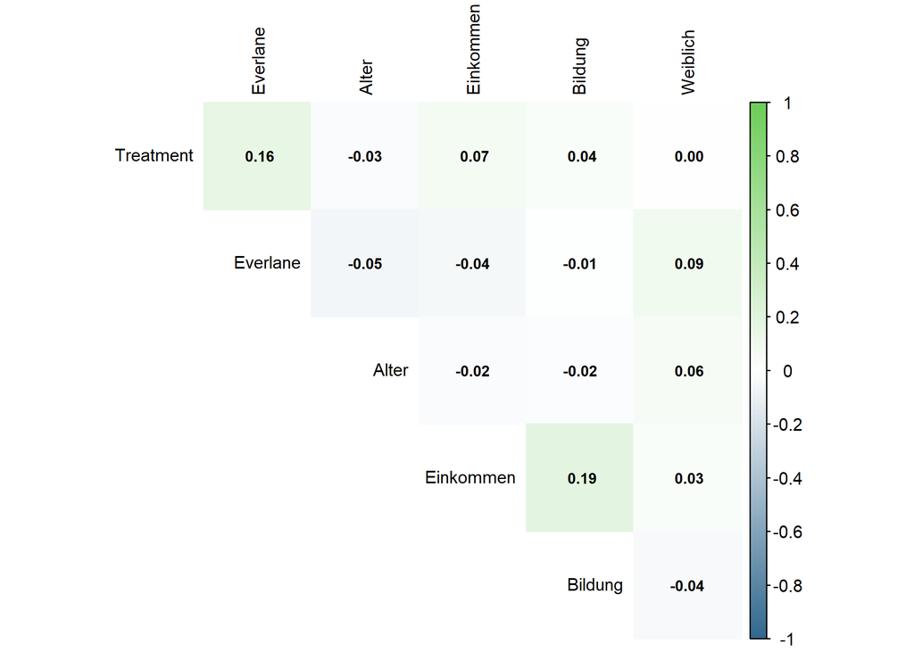

**Beschreibung der Grafik**  
Dargestellt ist eine Korrelationsmatrix auf Basis des Datensatzes. Es wird die Korrelation zwischen den Variablen Treatment, Everlane, Alter, Einkommen und Bildung aufgezeigt. Dabei ist die Stärke der Korrelationen anhand der Farbskala abzulesen. Blau bedeutet eine starke negative Korrelation, grün bedeutet eine starke positive Korrelation und weiß deutet auf keine Korrelation hin. Je kräftiger die Farben, desto stärker ist die Korrelation. Die Korrelation geht typischerweise von -1 bis 1.

**Interpretation der Grafik**  
Allgemein auffällig ist, dass relativ wenig Variablen miteinander korrelieren und wenn dann sehr schwach. Das ist zunächst ein gutes Zeichen, da eine Korrelation der Variablen untereinander nicht gewollt ist und zu Verzerrungen in der Analyse führen kann.

**Was bedeutet ein positiver Zusammenhang zwischen `treatment` und `everlane` im Kontext der Hypothese, dass Kostentransparenz die Entscheidung für Everlane beeinflusst?**  
Eine im Vergleich auffällig “hohe” Korrelation haben die Variablen Treatment und Everlane. Diese sind mit einem Wert von 0.16 postitiv korreliert. Die Variable Treatment gibt an, ob eine Person in der Treatment- oder Kontrollgruppe war, also ob sie Einsicht in die Kostenstruktur hatte oder nicht. Die Variable Everlane gibt an, ob die Personen sich für eine Geschenkkarte von Everlane oder J. Crew entschieden haben. Ein positiver Zusammenhang deutet hier also darauf hin, dass es einen Einfluss der Kostentransparenz auf die Entscheidung der Personen gibt. Personen die also Einsicht in die Kosten bekommen haben, tendieren eher dazu die Geschenkkarte von Everlane zu nehmen, was unsere Hypothese unterstützen würde. Dies ist aber noch keine kausale Schlussfolgerung.

**Warum kann eine Korrelation auf einen Zusammenhang hinweisen, aber nicht ausreichen, um einen kausalen Effekt nachzuweisen - selbst wenn wir wissen, dass `treatment` im Experiment zufällig zugewiesen wurde?**  
Korrelation bedeutet nicht gleich Kausalität, denn nur weil etwas zusammenhängt heißt es nicht, dass das eine aus dem anderen folgt. Selbst bei einem randomisierten Experiment, wie es hier vorliegt, kann es unterschiedliche Störfaktoren geben, die die Analyse beeinflussen. Um kausale Aussagen treffen zu können bedarf es einer Regressionsanalyse.

**Was nützt eine Korrelationsmatrix im Vergleich zu einem einfachen Mittelwertvergleich zwischen den Gruppen?**  
Bei einem einfachen Mittelwertvergleich sieht man lediglich, ob es einen Unterschied im Durchschnitt zwischen den zwei Gruppen gibt. Es werden also zwei Gruppen bezüglich einer Variablen verglichen. So können grobe Unterschiede festgestellt werden. Eine Korrelationsmatrix zeigt gleichzeitig lineare Zusammenhänge zwischen allen Variablen. Dies ist praktisch für eine spätere Regression.

7. In Aufgabe 1 und 2 haben Sie gelesen, dass den Teilnehmern ein Angebot gemacht wurde, eine Everlane-Gutscheinkarte anzunehmen. Erzeugen Sie eine geeignete Grafik, die den durchschnittlichen Anteil der angenommenen Angebote (d.h. den Anteil, in dem die Everlane-Karte gewählt wurde) getrennt für die Treatment- und die Kontrollgruppe darstellt. Fügen Sie in der Grafik zusätzlich den Standardfehler der Mittelwerte ein. Führen Sie einen T-Test durch, um zu prüfen, ob der Unterschied im Mittelwert zwischen der Treatment- und Kontrollgruppe statistisch signifikant ist, und geben Sie das Testergebnis (den p-Wert) deutlich sichtbar in der Grafik an. Achten Sie dabei auf eine verständliche Beschriftung Ihrer Grafik sowie auf einen aussagekräftigen Titel.

Beschreiben und interpretieren Sie ihre Grafik. Gehen Sie insbesondere auf folgende Fragen ein:

- Welche Aussage lässt sich auf Basis des durchgeführten T-Tests treffen?
- Welche der in den vorherigen Aufgaben (vgl. Aufgabe 4 und 5) analysierten Faktoren könnten dazu beigetragen haben, dass ein signifikanter Unterschied im Anteil angenommener Everlane-Angebote zwischen Treatment- und Kontrollgruppe beobachtet wird?

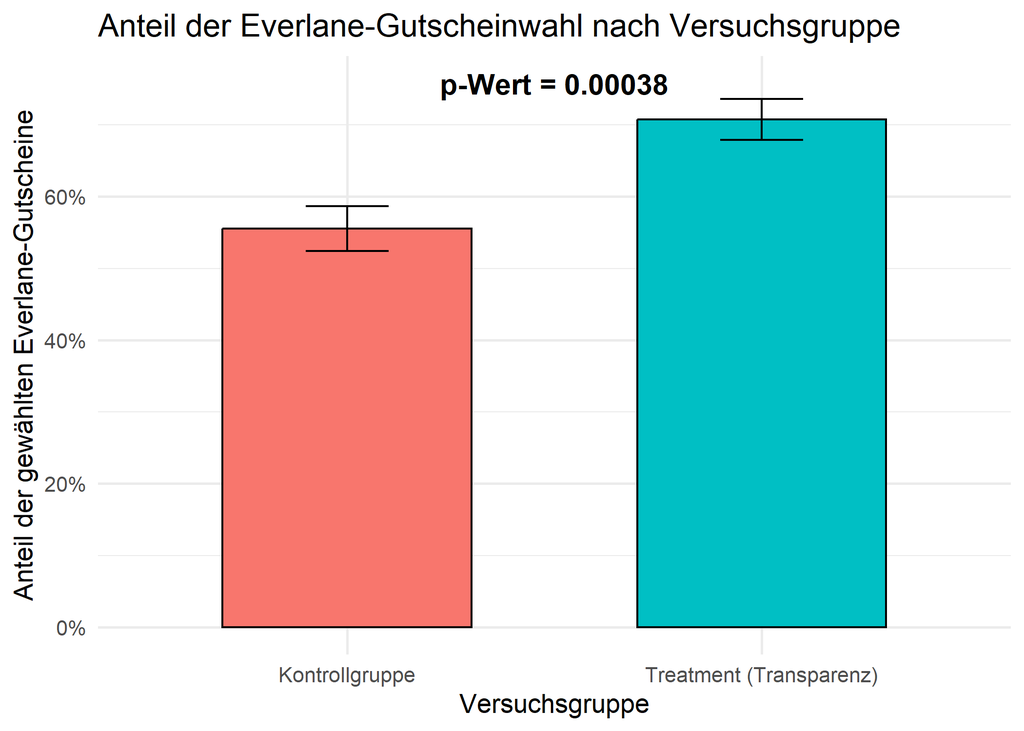

**Beschreibung der Grafik**  
Die erstellte Grafik zeigt den durchschnittlichen Anteil der Teilnehmer:innen, die sich im Experiment für den Everlane-Gutschein entschieden haben. Diese Entscheidung wird getrennt nach den beiden Versuchsgruppen – Treatmentgruppe und Kontrollgruppe – dargestellt.

Die Treatmentgruppe erhielt im Rahmen des Experiments eine Produktseite, auf der die Produktionskosten des angebotenen Rucksacks transparent offengelegt wurden. Diese sogenannte Kostentransparenz zeigte Informationen zu Material-, Arbeits-, Transportkosten usw. Die Kontrollgruppe sah hingegen dieselbe Produktseite ohne jegliche Preisaufschlüsselung. Beide Gruppen hatten anschließend die Möglichkeit, sich für einen von zwei Gutscheinen (Everlane oder J. Crew) zu entscheiden – ihre Wahl wurde als Indikator für Kaufinteresse bzw. Vertrauen gegenüber dem Anbieter interpretiert.

Die grafische Darstellung besteht aus zwei Balken, die den jeweiligen Mittelwert des Anteils an Everlane-Gutscheinwahlen je Gruppe abbilden. Die Balken enthalten zusätzlich Fehlerbalken, die den Standardfehler des Mittelwerts darstellen. Über den Balken ist zudem der p-Wert eines durchgeführten T-Tests eingeblendet, der prüft, ob der beobachtete Unterschied zwischen den Gruppen statistisch signifikant ist.

Die Interpretation dieser Ergebnisse ist eindeutig: Teilnehmer:innen, die die kostentransparente Produktseite sahen, entschieden sich signifikant häufiger für das Angebot von Everlane. Dies unterstützt die zentrale Hypothese der Studie, dass Kostentransparenz als Zeichen von Offenheit und Vertrauen wirkt und dadurch das Kaufinteresse erhöht.

**Welche Aussage lässt sich auf Basis des durchgeführten T-Tests treffen?**  
Der durchgeführte T-Test vergleicht die Mittelwerte der beiden Gruppen hinsichtlich ihrer Entscheidung für Everlane. Da der p-Wert deutlich unter dem konventionellen Signifikanzniveau von 0,05 liegt, können wir mit hoher Sicherheit sagen, dass der Unterschied nicht zufällig ist. Das bedeutet: Kostentransparenz hat einen signifikanten Einfluss auf die Entscheidung zugunsten des transparenten Anbieters. Dies liefert einen empirischen Beleg für die Wirkung von Transparenzmaßnahmen in der Kundenkommunikation.

**Welche Faktoren aus Aufgaben 4 und 5 könnten zur beobachteten Differenz beigetragen haben?**  
In den vorherigen Aufgaben, insbesondere in der Balancing-Tabelle aus Aufgabe 5, wurde überprüft, ob sich die beiden Gruppen hinsichtlich relevanter Hintergrundmerkmale wie Alter, Geschlecht, Einkommen und Bildung systematisch unterscheiden. Dabei zeigte sich, dass die Gruppen weitgehend ausgeglichen waren – was angesichts der randomisierten Zuweisung zu erwarten war.

Daher ist es für weiterführende Analysen sinnvoll, diese Variablen als Kontrollfaktoren mit aufzunehmen. So kann man sicherstellen, dass der beobachtete Effekt tatsächlich auf die Kostentransparenz zurückzuführen ist und nicht auf andere, unbeabsichtigte Unterschiede zwischen den Gruppen.

In den vorherigen Aufgaben des Projekts haben Sie sich bereits intensiv mit dem Experiment 1 auseinandergesetzt, in dem untersucht wurde, ob und wie die Offenlegung von Produktionskosten - also Kostentransparenz - das Konsumverhalten beeinflusst. Es wurde gezeigt: Wenn Konsument:innen transparent mitgeteilt wird, wie sich die Kosten eines Produkts zusammensetzen, steigt ihre Bereitschaft, bei dem entsprechend transparenten Unternehmen einzukaufen.

Diese Ergebnisse legen nahe, dass die Offenlegung sensibler Unternehmensinformationen (wie Produktionskosten) das Vertrauen der Konsument:innen in das Unternehmen stärkt und sie somit eher zu einem Kauf motiviert.

Doch was genau ist der psychologische Mechanismus hinter dieser Wirkung? Ist es tatsächlich das Vertrauen in das Unternehmen, das durch die Offenlegung sensibler Informationen gestärkt wird - und in der Folge die Kaufbereitschaft erhöht?

Um genau diese Frage zu beantworten, führen die Autoren ein weiteres Experiment durch, das den vermuteten psychologischen Vermittlungsmechanismus des Vertrauens genauer untersucht. Dabei wurde geprüft, ob Vertrauen tatsächlich als Mediator zwischen Kostentransparenz und Kaufinteresse wirkt. Hierzu wurde ein kontrolliertes Online-Experiment mit über 600 Teilnehmer:innen durchgeführt. Die Teilnehmenden wurden zufällig einer von zwei Bedingungen zugewiesen:

- In der **Kostentransparenz-Gruppe** (Treatment) wurde zusätzlich eine detaillierte Aufschlüsselung der Produktionskosten angegeben. Diese beinhaltete die einzelnen Kostenkomponenten (z.B. Kakaobutter, Verpackung, Arbeitskosten) sowie die Gesamtkosten der Schokoladentafel (vgl. Abbildung 2 im Anhang).
- In der **Kontrollgruppe** sahen die Teilnehmer die Verpackung einer fiktiven Schokoladenmarke namens „Cocoa Passion“. Diese enthielt nur die üblichen Informationen wie Zutaten, Nährwerte und eine Produktbeschreibung.

Ziel war es, zu untersuchen, ob die Offenlegung dieser sensiblen Informationen das Vertrauen der Konsument:innen in die Marke stärkt - und ob dieses Vertrauen wiederum die Kaufbereitschaft beeinflusst. In den nächsten Aufgaben werden Sie diese Studie genauer beleuchten, analysieren und evaluieren, ob sich die Hypothese empirisch bestätigen lässt.

8. Lesen Sie die Daten des zweiten Experiments (`Experiment2.csv`) in R ein. Nennen Sie den Datensatz `daten_exp2`. Benennen Sie die Variable `cost` in `treatment` um.

Untersuchen Sie, ob sich die Teilnehmer, die die Verpackung mit transparenter Kosteninformation gesehen haben, systematisch von jenen unterscheiden, die nur die Kontrollversion gesehen haben.

Erstellen Sie hierfür eine Balancing-Tabelle, in der Sie die Mittelwerte von Alter (age), Geschlecht (female), Einkommensstufe (income), Bildungsniveau (educ), Vertrauen (trust) und Kaufbereitschaft (wtb) zwischen den beiden Gruppen vergleichen, die Differenzen berechnen und mithilfe von T-Tests prüfen, ob diese Unterschiede statistisch signifikant sind. Nehmen Sie weiterhin die Anzahl an Beobachtungen in der Treatment- und in der Kontrollgruppe in ihre Tabelle mit auf.

Beschreiben und interpretieren Sie ihre Tabelle. Gehen Sie dabei insbesondere auf folgende Fragen ein:

- Was versteht man unter der Variable `wtb`?
- Was lässt sich aus der Größen der Stichprobe ableiten?
- Wo könnte es bei einer Regression (oder einem sonstigen Vergleich der Gruppen) zu Problemen kommen und was wären mögliche Auswirkungen?

*Hinweis:* Für die Beschreibung der `wtb` können Sie das bereitgestellte Readme nutzen.

Balancing-Tabelle: Vergleich der Gruppen im Experiment 2

| Variable | Mittelwert Treatment | Mittelwert Kontrolle | Differenz | p-Wert |
| --- | --- | --- | --- | --- |
| Alter | 34.06 | 36.27 | -2.21 | 0.02 |
| Weiblich | 0.48 | 0.42 | 0.06 | 0.21 |
| Einkommen | 6.79 | 6.96 | -0.17 | 0.37 |
| Bildung | 3.57 | 3.51 | 0.06 | 0.44 |
| Vertrauen | 5.27 | 4.82 | 0.45 | 0.00 |
| Kaufbereitschaft | 4.27 | 3.74 | 0.53 | 0.00 |

Hinweis:  
Anzahl Beobachtungen – Treatment: 306, Kontrolle: 308

**Beschreibung der Balancing-Tabelle**  
Die Tabelle zeigt für die wichtigsten demographischen und psychologischen Variablen den Mittelwert der Treatment- und der Kontrollgruppe sowie die Differenz zwischen diesen beiden Gruppen. Außerdem wurden für jede Variable T-Tests durchgeführt, um zu prüfen, ob die Unterschiede statistisch signifikant sind. Zusätzlich werden die Gruppengrößen (Anzahl der Beobachtungen) angegeben.

**Was versteht man unter der Variable wtb?**  
Die Variable wtb steht für „Willingness to Buy“ (Kaufbereitschaft). Sie misst die Bereitschaft der Teilnehmer:innen, die beworbene Schokoladenmarke zu kaufen. Laut Readme-Dokument beschreibt sie das Interesse bzw. die Wahrscheinlichkeit, dass die Proband:innen das Produkt kaufen würden, wobei höhere Werte eine höhere Kaufbereitschaft anzeigen. wtb ist somit die zentrale abhängige Variable, welche das Zielverhalten im Experiment darstellt.

**Was lässt sich aus der Größe der Stichprobe ableiten?**  
Die Stichprobengrößen der beiden Gruppen sind sehr ähnlich, was eine gute Voraussetzung für vergleichende statistische Analysen ist. Ein Gleichgewicht in der Gruppengröße sorgt für eine größere statistische Power und verringert Verzerrungen, die durch ungleiche Gruppengrößen entstehen könnten. Zudem spricht die hohe Anzahl an Beobachtungen (über 600 Teilnehmer:innen) dafür, dass die Analyse robuste und verlässliche Ergebnisse liefern kann.

**Wo könnte es bei einer Regression oder einem sonstigen Vergleich der Gruppen zu Problemen kommen und was wären mögliche Auswirkungen?**  
Obwohl die Zuteilung zufällig erfolgte, können kleinere systematische Unterschiede in den Kovariaten auftreten, z.B. wenn einzelne Variablen signifikante Differenzen zwischen Gruppen zeigen (p-Wert < 0.05). Dies kann zu Confounding führen, wenn diese Variablen mit der abhängigen Variable wtb zusammenhängen.

Solche Unterschiede müssen in einer Regressionsanalyse durch Kontrollvariablen (Alter, Geschlecht, Einkommen, Bildung, Vertrauen etc.) berücksichtigt werden, um den kausalen Effekt der Treatment-Bedingung auf die Kaufbereitschaft korrekt zu isolieren.

Falls einige Variablen sehr ungleich verteilt sind oder viele fehlende Werte vorhanden sind, könnten Verzerrungen oder eine geringere Aussagekraft der Ergebnisse auftreten.

9. In ihrem Datensatz gibt es einige Beobachtungen ohne vorhandene Werte. Behalten Sie nur die Beobachtungen bei denen vollständige Werte vorliegen. Erzeugen Sie eine geeignete Grafik, welche den durchschnittlichen Anteil der ‘Kaufbereitschaft’ im zweiten Experiment für die Treatment- und Kontrollgruppe darstellt.

Die Grafik soll:

- die Mittelwerte der Kaufbereitschaft für beide Gruppen zeigen,
- die zugehörigen Standardfehler als Fehlerbalken visualisieren und
- das Ergebnis des T-Tests, der die Mittelwertdifferenz prüft, direkt in die Grafik integrieren.

Beschreiben und interpretieren Sie ihre Grafik.

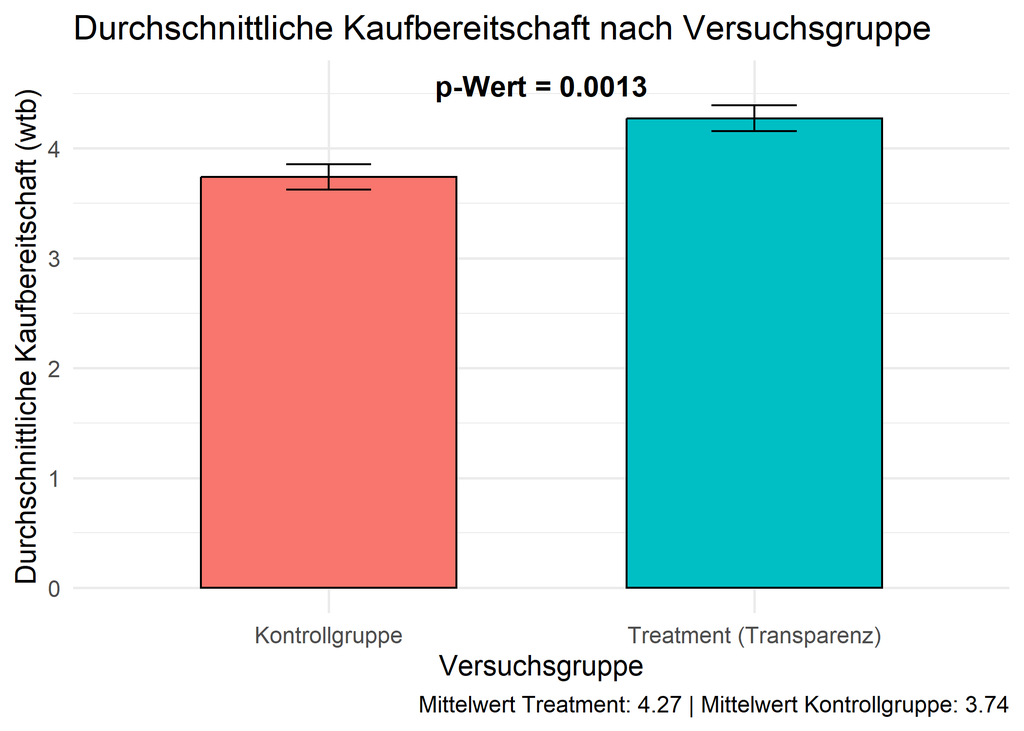

**Beschreibung der Grafik**  
Die Grafik zeigt die durchschnittliche Kaufbereitschaft („wtb“) der Teilnehmenden aus dem zweiten Experiment, getrennt nach den beiden Gruppen: der Treatmentgruppe mit Kostentransparenz und der Kontrollgruppe ohne diese Information. Die Balken repräsentieren jeweils den Mittelwert der Kaufbereitschaft in den beiden Gruppen. Zusätzlich sind Fehlerbalken eingezeichnet, die den Standardfehler der Mittelwerte anzeigen. Diese Fehlerbalken verdeutlichen, wie präzise der Mittelwert geschätzt wurde. Ein kleiner Standardfehler spricht für eine zuverlässige Mittelwertschätzung.

In der Grafik ist zudem der p-Wert des T-Tests abgebildet, der die statistische Signifikanz des Unterschieds zwischen den Gruppen prüft. Dieser p-Wert wird gut sichtbar platziert, um die Relevanz des Unterschieds in der Kaufbereitschaft zu unterstreichen.

**Interpretation der Grafik**  
Der berechnete p-Wert von 0,0013 liegt deutlich unter dem üblichen Schwellenwert von 0,05. Das bedeutet, dass der Unterschied in der Kaufbereitschaft zwischen der Treatment- und Kontrollgruppe statistisch signifikant ist. Die Nullhypothese, dass es keinen Unterschied zwischen den Gruppen gibt, wird somit verworfen. Konkret heißt das: Die Teilnehmenden, die eine transparente Aufschlüsselung der Produktionskosten erhalten haben, zeigen eine signifikant höhere Kaufbereitschaft als jene, die keine Kostentransparenz sahen.

Die Fehlerbalken sind vergleichsweise klein, was auf eine geringe Streuung und eine gute Genauigkeit der Mittelwerte hinweist. Dies erhöht das Vertrauen in die Zuverlässigkeit der Resultate.

Die Ergebnisse unterstützen die Hypothese, dass Kostentransparenz das Vertrauen in die Marke stärkt und dadurch die Bereitschaft zum Kauf erhöht. Das Experiment zeigt also einen positiven Einfluss von transparenter Information auf das Konsumentenverhalten.

Es ist jedoch wichtig, auch mögliche Einflüsse aus anderen Variablen oder systematische Unterschiede zwischen den Gruppen zu berücksichtigen, wie in Aufgabe 8 durch die Balancing-Tabelle geprüft. Diese könnten die Ergebnisse teilweise mit beeinflussen. Zudem wurde nur eine Stichprobe mit vollständigen Fällen betrachtet, was mögliche Verzerrungen durch fehlende Werte minimiert.

Insgesamt vermittelt die Grafik eine klare und überzeugende Evidenz, dass die Offenlegung der Produktionskosten die Kaufbereitschaft signifikant steigert.

Nachdem Sie nun die Differenzen in der Kaufabsicht zwischen der Treatment- und der Kontrollgruppe im zweiten Experiment überprüft und getestet haben, geht es im nächsten Schritt darum, den möglichen Mediator Vertrauen genauer zu untersuchen. Hierfür sollen Sie sich in einem ersten Schritt das Vertrauen der Personen allgemein anschauen, um einen Eindruck zu dieser wichtigen Variable zu bekommen. Dafür werden Personen anhand **hohem und niedrigem** Vertrauen und deren Kaufbereitschaft für das Produkt unterteilt.

10. Erstellen Sie eine oder mehrere geeignete Grafik(en), die den Zusammenhang zwischen Vertrauen (Trust) und der Kaufabsicht (WTB) **unabhängig** der beiden Treatment- und Kontrollgruppen darstellen. Achten Sie auf eine passende Darstellung der Informationen.

Die Grafik(en) sollen folgende Informationen enthalten:

- Unterteilen Sie ihre Daten in Personen mit `hohem` und `niedrigem` Vertrauen. Nutzen Sie für die Unterteilung den Median des Vertrauens in ihren Daten als Schwellenwert.
- Abhängig der Einstufungen in `hohes` und `niedriges` Vertrauen soll nun die durchschnittliche Kaufbereitschaft dargestellt werden. Hier soll die Grafik so dargestellt werden, dass auf der x-Achse das Vertrauensniveau (“hoch” und “niedrig”) und auf der y-Achse die entsprechende Kaufbereitschaft abgebildet wird.
- Berechnen Sie weiterhin die Mittelwerte der beiden Vertrauensgruppen und visualisieren diese in geeigneter Art und Weise in ihren Grafik(en).
- Führen Sie einen t-Test durch, um zu prüfen, ob die Mittelwertsunterschiede zwischen den beiden Vertrauensgruppen statistisch signifikant sind. Geben Sie den p-Wert in der Grafik an.

Beschreiben und interpretieren Sie ihre Grafik(en). Beantworten Sie insbesondere folgende Fragen:

- Welche Implikationen hat ein signifikanter Unterschied für die Rolle von Vertrauen auf Kaufentscheidungen?
- Wie stark unterscheidet sich die Kaufbereitschaft zwischen Personen mit hohem und niedrigem Vertrauen?
- Könnte auf Basis ihrer Darstellung Vertrauen als Mediator zwischen dem Treatment und der Kaufbereitschaft fungieren?

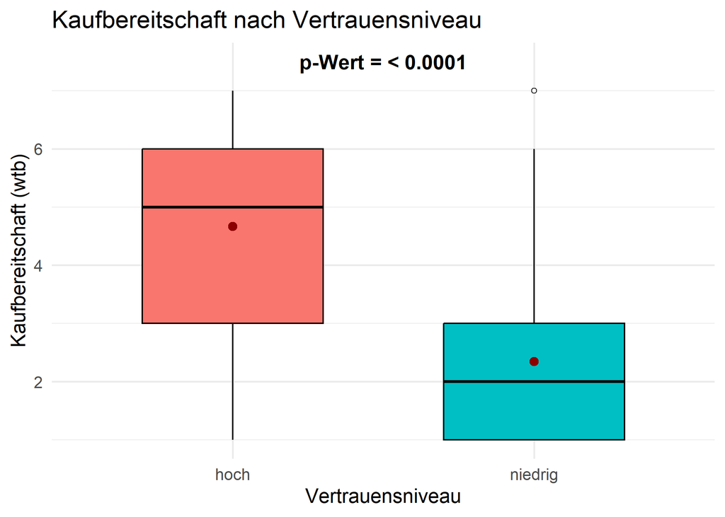

**Beschreibung der Grafik**  
Die dargestellte Grafik visualisiert die Verteilung der Kaufbereitschaft („wtb“) in Abhängigkeit vom Vertrauensniveau der Teilnehmer. Die Stichprobe wurde anhand des Medianwerts der Variable „trust“ in zwei Gruppen unterteilt: „hoch“ (Vertrauen ≥ Median) und „niedrig“ (Vertrauen < Median). Auf der x-Achse sind diese beiden Vertrauensgruppen abgetragen, während die y-Achse die Kaufbereitschaft abbildet. Die Boxplots zeigen die Verteilung der Kaufbereitschaft innerhalb der Gruppen, inklusive Median, Quartile und Ausreißer. Zusätzlich sind die Mittelwerte der beiden Gruppen als rote Punkte hervorgehoben. Oberhalb der Grafik wird der p-Wert eines unabhängigen t-Tests angegeben, der prüft, ob die Mittelwertunterschiede zwischen den Gruppen statistisch signifikant sind.

**Interprtation der Grafik**

**Welche Implikationen hat ein signifikanter Unterschied für die Rolle von Vertrauen auf Kaufentscheidungen?**  
Der t-Test ergibt einen p-Wert von < 0.0001, was deutlich unter dem üblichen Signifikanzniveau von 5 % liegt. Dies bedeutet, dass der Unterschied in der Kaufbereitschaft zwischen Personen mit hohem und niedrigem Vertrauen statistisch signifikant ist. Somit kann Vertrauen als ein zentraler Einflussfaktor auf die Kaufentscheidung angesehen werden, unabhängig von anderen experimentellen Bedingungen wie der Treatment-Zuordnung. Ein signifikanter Unterschied weist darauf hin, dass Vertrauen eine wichtige Rolle bei der Bewertung von Produkten und der Bereitschaft zu deren Kauf spielt.

**Könnte auf Basis ihrer Darstellung Vertrauen als Mediator zwischen dem Treatment und der Kaufbereitschaft fungieren?**  
Die Ergebnisse stützen die Annahme, dass Vertrauen als psychologischer Mediator wirken kann. Wenn die Treatment-Bedingung (z.B. Kostentransparenz) das Vertrauen erhöht - wie in früheren Aufgaben nachgewiesen -, und Vertrauen wiederum die Kaufbereitschaft signifikant beeinflusst, spricht dies für einen indirekten kausalen Pfad: Treatment -> Vertrauen -> Kaufbereitschaft

Damit liefert diese Analyse eine zentrale empirische Grundlage zur Validierung der theoretischen Hypothese der Autoren: Offenheit schafft Vertrauen - und Vertrauen fördert Konsum.

# Regressionsanalyse

Sie haben nun ihren Datensatz kennengelernt und es scheint so, als ob insbesondere Personen, welche transparente Kosten sehen, dazu neigen, das Produkt zu kaufen. Doch um ihre deskriptiven Analysen zu erhärten, wollen Sie im folgenden eine Analyse mittels Regressionen durchführen.

11. Betrachten Sie hier noch einmal das erste Experiment (`daten_exp1`). Führen Sie eine Regression durch, bei der Ihnen `everlane` als abhängige Variable dient. Als erklärende Variable nutzen Sie das `treatment`. Erstellen sie eine weitere Regression, die zusätzlich noch für die folgenden Variablen kontrolliert:
- Alter
- Bildungsstufe
- Einkommen
- Geschlecht

Stellen Sie die Regressionsergebnisse in einer Tabelle mit stargazer oder modelsummary dar!

Beschreiben und interpretieren Sie ihre Ergebnisse. Gehen Sie insbesondere auf folgende Fragen ein:

- Lässt sich der Effekt des Treatments auf die Entscheidung der Kunden kausal interpretieren?
- Ist es wichtig auf weitere Faktoren zu kontrollieren?
- Beziehen Sie sich hier auch auf die Ergebnisse aus Aufgabe 5.

|  | *abhängige Variable:* | Everlane |
| --- | --- | --- |
| Treatment (Transparenz) | 0.152*** | 0.155*** |
|  | [0.069, 0.235] | [0.071, 0.238] |
| Alter |  | -0.002 |
|  |  | [-0.006, 0.001] |
| Bildung |  | -0.001 |
|  |  | [-0.051, 0.050] |
| Einkommen |  | -0.012 |
|  |  | [-0.029, 0.006] |
| Weiblich |  | 0.091* |
|  |  | [0.008, 0.175] |
| Num.Obs. | 505 | 505 |
| R2 | 0.025 | 0.039 |
| R2 Adj. | 0.023 | 0.030 |
| F | 12.797 | 4.072 |

+ p < 0.1, * p < 0.05, ** p < 0.01, *** p < 0.001

**Beschreibung der Grafik**  
Die Tabelle zeigt die Ergebnisse zweier linearer Regressionsmodelle, die den Einfluss der Kostentransparenz (Treatment) auf die Wahl eines Everlane-Gutscheins untersuchen. In Modell 1 wird ausschließlich das Treatment als Prädiktor berücksichtigt, während Modell 2 zusätzlich für Alter, Bildung, Einkommen und Geschlecht kontrolliert. Die abhängige Variable „everlane“ ist binär kodiert (1 = Everlane gewählt, 0 = J.Crew gewählt), sodass die Koeffizienten als Änderung der Wahlwahrscheinlichkeit in Prozentpunkten interpretiert werden können.

**Interpretation der Regressionsergebnisse**  
In beiden Modellen zeigt sich ein statistisch hoch signifikanter positiver Effekt der Treatment-Variable. In Modell 1 steigt die Wahrscheinlichkeit, dass sich Personen für Everlane entscheiden, um ca. 15.2 Prozentpunkte, wenn sie der Treatmentgruppe zugeordnet sind. Modell 2, das zusätzlich soziodemografische Merkmale berücksichtigt, zeigt mit ca. 15.5 Prozentpunkten einen fast identischen Effekt, was für die Robustheit des Zusammenhangs spricht. Von den Kontrollvariablen ist einzig das Geschlecht signifikant: Weibliche Personen haben eine rund 9 Prozentpunkte höhere Wahrscheinlichkeit, sich für den Everlane-Gutschein zu entscheiden.

**Lässt sich der Effekt des Treatments auf die Entscheidung der Kunden kausal interpretieren?**  
Ja, der Effekt lässt sich als kausal interpretieren. Die Zuweisung zu Treatment- und Kontrollgruppe erfolgte im Rahmen eines randomisierten Experiments. Dadurch wird sichergestellt, dass systematische Verzerrungen durch unbeobachtete Drittvariablen weitestgehend ausgeschlossen sind. Die Randomisierung ist eine zentrale Voraussetzung für die Identifikation kausaler Effekte.

**Ist es wichtig auf weitere Faktoren zu kontrollieren?**  
Prinzipiell ist eine Kontrolle weiterer Variablen in einem randomisierten Experiment nicht zwingend erforderlich, da die Gruppen durch die Randomisierung bereits vergleichbar sind. Dennoch kann es methodisch sinnvoll sein, um etwaige Ungleichgewichte, wie sie in Aufgabe 5 für das Einkommen (p = 0.10) beobachtet wurden, zu berücksichtigen. In diesem Fall bestätigt das Modell mit Kontrollvariablen den Haupteffekt und zeigt, dass dieser nicht durch Kovariaten verzerrt ist. Das erhöht die statistische Präzision und stärkt die Aussagekraft.

**Bezug zu Aufgabe 5: Balancing-Tabelle**  
Die Balancing-Tabelle aus Aufgabe 5 zeigte keine signifikanten Unterschiede zwischen Treatment- und Kontrollgruppe in Bezug auf Alter, Geschlecht, Einkommen und Bildung. Dies spricht für eine gelungene Randomisierung. Der leicht erhöhte p-Wert beim Einkommen rechtfertigt jedoch, diese Variable im Regressionsmodell zu berücksichtigen. Die Ergebnisse beider Modelle zeigen, dass der Treatment-Effekt nicht durch Kovariaten beeinflusst wird, was ein weiteres Indiz für die Robustheit und Validität des Effekts darstellt. ——

Während die bisherigen Analysen zeigen, dass das Treatment einen Effekt hat, stellt sich nun die Frage, warum das so ist. Nun sollten Sie im weiteren Verlauf durch vertiefende Regressionsanalysen prüfen, ob dies auf das Vertrauen der Kunden zurückzuführen ist. Dazu betrachten Sie noch einmal den Datensatz zu Experiment 2 (`daten_exp2`) und untersuchen, ob das Treatment (Kunden sehen transparente Kostenstruktur) zu einer höheren Kaufabsicht führt, weil sie das Vertrauen der Konsumenten in das Unternehmen stärkt.

12. Schauen Sie sich den Einfluss der Kostentransparenz auf die Kaufabsicht in den folgenden zwei Regressionen genauer an und zeigen Sie ihre Ergebnisse nebeneinander:

**1. Regression:** Abhängige Variable ist die Kaufabsicht; die erklärende Variable ist das Treatment.

**2. Regression:** Wie in der 1. Regression, doch kontrollieren Sie hier zusätzlich auf die Variablen Alter, Einkommensniveau, Bildungsstufe und Geschlecht.

Stellen Sie die Regressionsergebnisse in einer Tabelle mit stargazer oder modelsummary dar!

Beschreiben und interpretieren Sie ihre Ergebnisse allgemein. Gehen Sie weiterhin auch speziell auf folgende Fragen ein:

- Sollten die Kontrollvariablen in ihrer zweiten Regression den Koeffizienten des Treatments ändern? Was würden Sie erwarten und warum? Nutzen Sie hierzu die Ergebnisse aus Aufgabe 8.
  - Vergleichen Sie die Regressionskoeffizienten der Treatment-Variable in der ersten und zweiten Regression. Gibt es hier einen signifikanten Unterschied in der Größe des Effekts?
- Bringt ihnen die Regression Vorteile gegenüber einer reinen Darstellung der Mittelwerte wie in Aufgabe 9?
- Ist der Effekt des Treatments auf die Kaufabsicht ihrer Ansicht nach kausal interpretierbar?
  - Welche Voraussetzungen müssen erfüllt sein, damit man diesen Regressionskoeffizienten als kausalen Effekt interpretieren kann?
  - Überlegen Sie sich, wie sich das Ergebnis verändern würde, wenn zusätzlich Vertrauen (trust) in das Modell aufgenommen wird. Würde sich der Effekt von `treatment` verändern? Warum oder warum nicht?

|  | *abhängige Variable:* | Kaufabsicht (wtb) |
| --- | --- | --- |
| Treatment (Transparenz) | 0.532** | 0.501** |
|  | (0.165) | (0.166) |
| Alter |  | -0.013+ |
|  |  | (0.007) |
| Bildung |  | 0.102 |
|  |  | (0.099) |
| Einkommen |  | 0.023 |
|  |  | (0.036) |
| Weiblich |  | -0.001 |
|  |  | (0.168) |
| Num.Obs. | 601 | 601 |
| R2 | 0.017 | 0.025 |
| R2 Adj. | 0.015 | 0.016 |
| F | 10.435 | 3.009 |

+ p < 0.1, * p < 0.05, ** p < 0.01, *** p < 0.001

**Beschreibung der Tabelle**  
Die dargestellte Tabelle zeigt die Ergebnisse zweier Regressionsmodelle zur Erklärung der Kaufabsicht (wtb). In Modell 1 ist nur die Variable treatment (Kostentransparenz) als erklärende Variable enthalten. In Modell 2 werden zusätzlich demografische Kontrollvariablen einbezogen: Alter (age), Einkommen (income), Bildung (educ) und Geschlecht (female). Ziel ist es zu prüfen, ob der beobachtete Effekt der Kostentransparenz auf die Kaufabsicht auch nach Kontrolle relevanter Drittvariablen bestehen bleibt.

**Welche Vorteile bringt die Regression gegenüber dem Mittelwertvergleich (Aufgabe 9)?**  
Die Regressionsanalyse bietet den Vorteil, mehrere Einflussfaktoren gleichzeitig berücksichtigen zu können. Im Gegensatz zum Mittelwertvergleich isoliert sie gezielt den Effekt des Treatments und kann dabei potenzielle Störfaktoren kontrollieren. So kann z.B. ausgeschlossen werden, dass kleine Ungleichgewichte in Alter oder Einkommen den beobachteten Effekt erklären. Darüber hinaus lässt sich die statistische Signifikanz präziser beurteilen. Dadurch ist die Regression deutlich aussagekräftiger und methodisch überlegen gegenüber einem einfachen Gruppenvergleich.

**Was passiert, wenn Vertrauen (trust) in das Modell aufgenommen wird?**  
Wenn die Variable trust in das Regressionsmodell aufgenommen wird, ist zu erwarten, dass sich der Effekt von treatment reduziert. Der Grund liegt darin, dass Vertrauen als psychologischer Vermittlungsmechanismus zwischen Kostentransparenz und Kaufabsicht wirkt. Kostentransparenz erhöht das Vertrauen der Konsumenten in das Unternehmen, und dieses Vertrauen wiederum steigert die Bereitschaft zum Kauf. Wird trust in der Regression berücksichtigt, wird also ein Teil des Effekts von treatment über trust erklärt – was typisch für eine Mediation ist.

Sie haben nun gesehen, dass es auch hier einen direkten Effekt des Treatments (transparente Kostenstrukur) auf die Kaufabsicht gibt. Doch um die dahinter liegenden Mechanismen zu verstehen, müssen Sie tiefer in psychologische Prozesse eintauchen. Experiment 2 zeigt dafür ein entsprechendes Design, um zu testen, ob Vertrauen als vermittelnder Mechanismus eine Rolle spielt. Im nächsten Schritt analysieren Sie nun selbst diese Beziehung mit theoretischen Modellen und Regressionsmethoden, um ein Gefühl dafür zu bekommen, wie sich direkte und indirekte Effekte voneinander unterscheiden.

13. Bevor Sie im nächsten Schritt ein konkretes DAG zu einem psychologischen Mediationsmechanismus erstellen, machen Sie sich zunächst mit den theoretischen Grundlagen von Directed Acyclic Graphs (DAGs) vertraut. DAGs (gerichtete azyklische Graphen) sind ein nützliches Werkzeug in der Kausalanalyse.

Beantworten Sie folgende theoretische Fragen zu DAGs:

- Wofür werden DAGs in der empirischen Forschung verwendet?
- Nennen und beschreiben Sie zwei zentrale Knotentypen in einem DAG: Confounder und Mediator.
- Worin besteht der zentrale Unterschied, ob Vertrauen als Kontrollvariable (Confounder) oder als Mediator behandelt wird - und warum ist Letzteres entscheidend für das Verständnis psychologischer Prozesse im vorliegenden Experiment?

**Wofür werden DAGs in der empirischen Forschung verwendet?**  
DAGs (Directed Acyclic Graphs) dienen in der empirischen Forschung als grafisches Instrument zur Darstellung und Analyse kausaler Strukturen. Sie helfen dabei, die Beziehungen zwischen Variablen klar zu visualisieren und erlauben es, auf Basis dieser Struktur zu bestimmen, welche Variablen kontrolliert werden müssen, um einen unverzerrten kausalen Effekt zu identifizieren. Darüber hinaus machen DAGs implizite Annahmen explizit, erleichtern die Kommunikation komplexer Modellüberlegungen und sind besonders nützlich, um Verzerrungen durch Confounding oder Mediation zu erkennen und zu vermeiden. In der kausalen Inferenz stellen sie somit ein unverzichtbares Werkzeug dar, um Studien valide zu planen und zu interpretieren.

**Zwei zentrale Knotentypen in einem DAG: Confounder und Mediator**  
**Confounder (Störvariable):**  
Ein Confounder ist eine Variable, die sowohl die unabhängige Variable (z.B. Treatment) als auch die abhängige Variable (z.B. Kaufabsicht) beeinflusst. Wird ein Confounder nicht kontrolliert, entsteht ein verzerrter Zusammenhang, da ein sogenannter “Backdoor Path” offenbleibt. Um eine unverzerrte Schätzung des kausalen Effekts zu erhalten, muss dieser Pfad geschlossen, also der Confounder kontrolliert werden.

**Mediator (Vermittler):**  
Ein Mediator ist eine Variable, die kausal zwischen der unabhängigen und der abhängigen Variable liegt. Er erklärt, wie ein kausaler Effekt zustande kommt - also über welchen Mechanismus die Ursache auf die Wirkung wirkt. Mediatoren sind zentral, wenn es darum geht, psychologische Prozesse zu verstehen, da sie den kausalen Pfad konkretisieren, über den eine Intervention wirkt.

**Worin besteht der zentrale Unterschied, ob Vertrauen als Kontrollvariable (Confounder) oder als Mediator behandelt wird - und warum ist Letzteres entscheidend für das Verständnis psychologischer Prozesse im vorliegenden Experiment?**  
Im vorliegenden Experiment 2 ist Vertrauen eindeutig als Mediator zu interpretieren, nicht als Confounder. Das Vertrauen wurde nach der Treatment-Zuweisung erfasst, kann also nicht kausal vor dem Treatment liegen. Es ist vielmehr ein potenzieller Wirkmechanismus, über den das Treatment auf die Kaufabsicht wirkt. Die Annahme ist: Kostentransparenz stärkt Vertrauen – und höheres Vertrauen erhöht die Kaufbereitschaft.

Behandelte man Vertrauen fälschlicherweise als Confounder und kontrollierte es direkt, würde man einen Teil des kausalen Effekts des Treatments “herausrechnen”, obwohl er erklärter Bestandteil des Wirkmechanismus ist. Das hätte zur Folge, dass der Effekt des Treatments unterschätzt wird.

Gerade bei der Untersuchung psychologischer Prozesse ist es entscheidend, Mediatoren nicht vorschnell als Störfaktoren zu behandeln, sondern gezielt ihren vermittelnden Einfluss zu analysieren - etwa durch Mediationsanalysen. Nur so lässt sich differenziert verstehen, warum ein Treatment wirkt - und nicht nur ob es wirkt.

14. Nutzen Sie nun das Directed Acyclic Graph (DAG), um die Beziehungen zwischen den Variablen Treatment (T), Vertrauen (V) und Kaufbereitschaft (K) zu analysieren und den vermuteten Mediationsmechanismus zu untersuchen.

Beschreiben und interpretieren Sie ihr DAG und die Beziehungen zwischen den Variablen. Gehen Sie insbesondere auf folgende Fragen und Aspekte ein:

- Begründen und erklären Sie die Struktur und den Aufbau ihres DAGs.
- Welche Annahmen müssen getroffen werden, damit Vertrauen tatsächlich als Mediator interpretiert werden kann?
- Welche Verzerrungen oder Störfaktoren könnten den Mediator-Effekt von Vertrauen beeinflussen? Wie könnte dies die Ergebnisse verzerren?

*Hinweis 1:* Für die Erstellung des DAGs können Sie das Paket `dagify` verwenden. Als Grundlage und Hilfsmittel können Sie die Vorlesungsfolien nutzen.

*Hinweis 2:* Eine direkte Visualisierung des DAGs in `R` ist schön, aber keine Pflicht. Sie können das DAG auch in Word/PowerPoint zeichnen und ihre Grafik mittels `include_graphics()` einfügen.

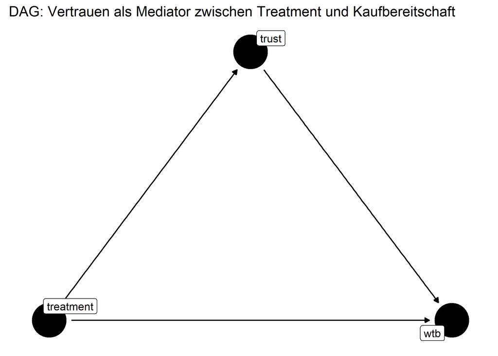

**Beschreibung des DAGs**  
Die Grafik zeigt das DAG, welches die Beziehung zwischen den drei Variablen treatment (Kosteneinsicht), trust (Vertrauen) und wtb (Kaufbereitschaft) zeigt. Die drei Variablen sind hier durch die runden Punkte dargestellt, wobei die kausalen Verhältnisse durch die Pfeile gezeigt werden, welche jeweils nur in eine Richtung zeigen.

**Interpretation des DAGs**  
Das DAG zeigt hier zwei Wege. Einmal den direkten Effekt von treatment auf die Kaufbereitschaft (wtb) und einmal den indirekten Effekt von treatment über Vertrauen (trust), als Mediator, auf die Kaufbereitschaft. Die Hauptannahme ist, dass treatment durch Erhöhung der Transparenz das Vertrauen in das Unternehmen erhöht. Dieses gesteigerte Vertrauen wiederum erhöht die Kaufbereitschaft. Zusätzlich kann es einen direkten Einfluss von treatment auf die Kaufbereitschaft geben – unabhängig vom Vertrauen.

**Welche Annahmen müssen getroffen werden, damit Vertrauen tatsächlich als Mediator interpretiert werden kann?**  
Damit Vertrauen tatsächlich als Mediator in diesem Modell interpretiert werden darf muss zunächst die Kausalität gegeben sein. Treatment muss kausal zu einer Veränderung des Vertrauens führen und Vertrauen muss kausal zu einer Veränderung in der Kaufbereitschaft führen. Außerdem dürfen keine unbeobachteten Variablen existieren, die gleichzeitig Vertrauen und Kaufbereitschaft beeinflussen (z.B. Grundvertrauen in Marken oder Kaufneigung). Auch zwischen treatment und Vertrauen darf kein unbeobachteter Confounder existieren, aber hier hilft die Randomisierung von treatment. Die letzte Annahme, die erfüllt sein muss ist, dass es keine Rückwirkungen der Variablen gibt. Die Kaufentscheidung sollte also nicht auf den Mediator (trust) zurückwirken. Dies stellt jedoch eine Grundannahme in jedem DAG dar.

**Welche Verzerrungen oder Störfaktoren könnten den Mediator-Effekt von Vertrauen beeinflussen? Wie könnte dies die Ergebnisse verzerren?**  
Ein Störfaktor könnte das allgemeine Grundvertrauen der Personen sein. Es gibt Personen die von sich aus eher skeptischer sind oder auch Personen, welche von Grund auf schneller vertrauen. Außerdem könnte die generelle Kaufbereitschaft eine Rolle spielen. Personen, die generell gerne oder viel kaufen, zeigen eventuell eine höhere Kaufbereitschaft unabhängig vom Vertrauen. Auch eine vorherige Markenkenntniss von Everlane könnte dazu führen, dass diese Personen von vornherein mehr Vertrauen in das Unternehmen haben. Wenn solche unbeobachteten Drittvariablen nicht kontrolliert werden, wird die Beziehung zwischen Vertrauen und Kaufbereitschaft verzerrt, obwohl diese Verzerrung nicht durch treatment entstanden ist. Das würde dazu führen, dass wir den indirekten Effekt über Vertrauen überschätzen.

15. Führen Sie nun eine Regression durch, bei der Ihnen `trust` (Vertrauen) als abhängige Variable dient. Weiterhin soll ihnen `treatment` als erklärende Variable dienen. Erstellen sie eine weitere Regression, die zusätzlich noch für die folgenden Variablen kontrolliert: Alter, Einkommensniveau, Bildungsstufe und ob die Personen weiblich sind.

Stellen Sie die Regressionsergebnisse in einer Tabelle mit stargazer oder modelsummary dar!

Beschreiben und interpretieren Sie ihre Ergebnisse. Gehen Sie bei der Interpretation der Ergebnisse insbesondere auf folgende Fragen ein:

- Macht es ihrer Ansicht nach Sinn auf die zusätzlichen Variablen in Regression 2 zu kontrollieren? Worauf müssen Sie besonders achten?
- Was bedeutet ein signifikanter positiver Koeffizient für treatment in Bezug auf Vertrauen?
- Warum ist dieser Pfad (Treatment ➝ Trust) notwendig, damit eine Mediation überhaupt möglich ist?
- Überlegen Sie, ob andere Faktoren, die Sie möglicherweise nicht berücksichtigt haben, diesen Zusammenhang ebenfalls erklären könnten.

|  | *abhängige Variable:* | Vertrauen (trust) |
| --- | --- | --- |
| Treatment (Transparenz) | 0.473*** | 0.454*** |
|  | (0.112) | (0.113) |
| Alter |  | -0.001 |
|  |  | (0.005) |
| Einkommen |  | -0.021 |
|  |  | (0.024) |
| Bildung |  | 0.058 |
|  |  | (0.067) |
| Weiblich |  | 0.179 |
|  |  | (0.114) |
| Num.Obs. | 601 | 601 |
| R2 | 0.029 | 0.035 |
| R2 Adj. | 0.027 | 0.027 |
| F | 17.791 | 4.291 |

+ p < 0.1, * p < 0.05, ** p < 0.01, *** p < 0.001

**Beschreibung der Regressionsanalyse**  
Die durchgeführte Regressionsanalyse untersucht den Einfluss der Kostentransparenz (Treatment) auf das Vertrauen (Trust) in das Unternehmen. In Modell 1 wird ausschließlich der Effekt von Treatment auf Vertrauen geschätzt. In Modell 2 werden zusätzlich Kontrollvariablen berücksichtigt: Alter, Einkommen, Bildung und Geschlecht.

In beiden Modellen zeigt sich ein positiver und signifikanter Koeffizient für Treatment, was darauf hindeutet, dass Personen, die transparente Kosteninformationen erhalten haben, dem Unternehmen signifikant mehr Vertrauen entgegenbringen als jene in der Kontrollgruppe. Die Aufnahme der Kontrollvariablen in Modell 2 verändert die Schätzung des Effekts nur minimal, was auf robuste Ergebnisse hindeutet.

**Interpretation und Beantwortung der Fragen:**

**Macht es Sinn, Kontrollvariablen in Regression 2 zu kontrollieren? Worauf muss man achten?**  
Ja, es ist methodisch sinnvoll, da kleinere Rest-Ungleichgewichte in den Kovariaten zwischen Treatment- und Kontrollgruppe (wie z.B. beim Alter in Aufgabe 8) dennoch bestehen können. Diese Kontrolle hilft, die Schätzung effizienter zu machen und potenzielle Confounding-Effekte auszuschließen.

Wichtig ist jedoch: Vertrauen selbst darf nicht als Confounder behandelt werden, sondern ist hier die abhängige Variable, nicht eine zu kontrollierende Variable. Zudem sollten nur prä-treatment-Variablen kontrolliert werden, also solche, die zeitlich vor der Treatment-Zuweisung feststehen.

**Was bedeutet ein signifikanter positiver Treatment-Koeffizient in Bezug auf Vertrauen?**  
Ein signifikanter positiver Koeffizient bedeutet, dass Kostentransparenz tatsächlich das Vertrauen der Konsument:innen in die Marke stärkt. Dieser Effekt ist zentral für die psychologische Wirkung des Treatments und legt nahe, dass Vertrauen ein wirksamer Mechanismus ist, durch den Transparenz auf Konsumverhalten wirkt.

**Warum ist dieser Pfad (Treatment ➝ Trust) notwendig, damit eine Mediation überhaupt möglich ist?**  
Dass eine Mediation theoretisch und empirisch nachgewiesen werden kann, muss der vermittelnde Faktor - in diesem Fall Vertrauen - kausal vom Treatment beeinflusst werden. Nur wenn das Treatment tatsächlich zu einer Veränderung im Vertrauen führt, kann Vertrauen als vermittelnde Instanz erklären, wie das Treatment auf die Kaufabsicht wirkt. Fehlt dieser Zusammenhang, wäre Vertrauen nicht Teil des Wirkmechanismus - eine Mediation wäre ausgeschlossen. Der Pfad Treatment ➝ Trust bildet also den ersten notwendigen Baustein eines indirekten Effekts, ohne den sich keine psychologische Wirkungskette ableiten lässt.

**Welche alternativen Erklärungen könnten den Zusammenhang zwischen Treatment und Vertrauen verzerren?**  
Obwohl das Experiment durch Randomisierung eine starke Grundlage für kausale Inferenz bietet, können nicht beobachtete Drittvariablen dennoch subtil Einfluss auf den Zusammenhang zwischen Kostentransparenz (Treatment) und Vertrauen nehmen. Zu den potenziellen konfundierenden Faktoren zählen:

**Allgemeine Vertrauensneigung:** Manche Personen sind grundsätzlich vertrauensvoller gegenüber Marken und Unternehmen - unabhängig vom konkreten Verhalten dieser Marken. Diese dispositionelle Tendenz könnte sowohl die Reaktion auf das Treatment als auch die gemessene Vertrauensbewertung beeinflussen.

**Persönliche Konsum- und Markenorientierung:** Personen, die besonders wertebasiert oder ethikorientiert einkaufen, könnten stärker auf Transparenzmaßnahmen ansprechen - unabhängig davon, ob diese Maßnahme zufällig im Experiment zugewiesen wurde.

**Vorwissen oder Erfahrung mit Everlane oder vergleichbaren Marken:** Personen, die bereits zuvor mit nachhaltigen Marken vertraut waren oder bewusst kostentransparente Anbieter aufsuchen, könnten von sich aus mehr Vertrauen zeigen - selbst ohne unmittelbaren Treatment-Effekt.

**Soziale Erwünschtheit und Antworttendenzen:** Da Vertrauen eine moralisch positiv bewertete Einstellung ist, könnten Personen dazu neigen, sozial erwünscht zu antworten, wenn sie ein Unternehmen sehen, das offen mit Informationen umgeht - unabhängig davon, ob sie dem Unternehmen tatsächlich mehr vertrauen.

**Kulturelle oder politische Wertorientierungen:** Personen mit einem hohen Bedürfnis nach Fairness, Gerechtigkeit oder unternehmensethischer Verantwortung könnten besonders empfänglich für transparente Preiskommunikation sein. Diese latenten Werthaltungen wurden jedoch nicht im Experiment erfasst.

Trotz randomisierter Gruppenzuweisung können solche unbeobachteten Haltungen oder Vorerfahrungen zu einer partiellen Verzerrung führen. Sie verdeutlichen, dass auch in experimentellen Designs nicht jede Form von Verzerrung ausgeschlossen werden kann - insbesondere wenn psychologische Konstrukte wie „Vertrauen“ im Mittelpunkt stehen, die nicht rein beobachtungsbasiert, sondern subjektiv bewertet werden.

16. Nachdem Sie nun den Effekt des Treatments auf das Vertrauen geschätzt und ausgewertet haben, sollen Sie nun testen, ob das Vertrauen als Mediator zwischen Treatment und Kaufabsicht wirkt.

Führen Sie eine Regression durch, bei der Ihnen die Kaufbereitschaft als abhängige Variable dient. Weiterhin sollen die erklärende Variablen nun `treatment`, sowie das Vertrauen (`trust`) umfassen. Erstellen sie eine weitere Regression, die zusätzlich noch auf Alter, Einkommensniveau, Bildungsstufe und ob die Personen weiblich sind, kontrolliert.

Stellen Sie die Regressionsergebnisse passend in einer Tabelle dar!

Beschreiben und interpretieren Sie ihre Ergebnisse. Gehen Sie bei der Interpretation der Ergebnisse insbesondere auf folgende Fragen ein:

- Was könnten Ihrer Ansicht nach Gründe sein, dass `treatment` jetzt nicht mehr signifkant ist? Woran könnt das im Detail liegen?
- Warum ist es wichtig, `trust` und `treatment` gemeinsam in einem Modell zu betrachten?
- Warum könnte `trust` eine “notwendige Bedingung” sein, damit Transparenz der Kostenstruktur zu höherer Kaufbereitschaft führt?

|  | *abhängige Variable:* | Kaufabsicht (wtb) |
| --- | --- | --- |
| Treatment (Transparenz) | 0.148 | 0.129 |
|  | (0.140) | (0.140) |
| Vertrauen | 0.813*** | 0.818*** |
|  | (0.050) | (0.050) |
| Alter |  | -0.013* |
|  |  | (0.006) |
| Einkommen |  | 0.041 |
|  |  | (0.030) |
| Bildung |  | 0.055 |
|  |  | (0.082) |
| Weiblich |  | -0.148 |
|  |  | (0.140) |
| Num.Obs. | 601 | 601 |
| R2 | 0.317 | 0.327 |
| R2 Adj. | 0.315 | 0.320 |
| F | 139.008 | 48.027 |

+ p < 0.1, * p < 0.05, ** p < 0.01, *** p < 0.001

**Beschreibung der Regressionsanalyse**  
In der Grafik lassen sich zwei durchgeführte Regressionen erkennen, die den Einfluss von treatment und Vertrauen auf die Kaufbereitschaft zeigen soll. Die erste Regression beinhaltet nur die Variablen treatment und trust als erklärende Variablen. In der zweiten Regression werden zusätzlich noch die Variablen age, income, educ und female mitaufgenommen.

**Warum ist `treatment` jetzt nicht mehr signifkant? Woran könnte das im Detail liegen?**  
Auffällig im Gegensatz zu vorherigen Regressionen ist, dass die Variable treatment nun nicht mehr signifikant ist. Das dürfte vor allem daran liegen, dass hier das Vertrauen beachtet wurde, das wie aus vorherigen Erkenntnissen bekannt einen Einfluss auf die Kaufbereitschaft hat. Da trust aber ein Mediator ist, könnte der Effekt von treatment auf die Kaufbereitschaft vollständig über das Vertrauen vermittelt werden. Weil trust im Modell enthalten ist und selbst stark signifikant ist, kann dies bedeuten, dass der direkte Effekt von treatment auf die Kaufbereitschaft nicht mehr eigenständig relevant ist.

**Warum ist es wichtig, `trust` und `treatment` gemeinsam in einem Modell zu betrachten?**  
Wenn Vertrauen wie in vorherigen Regressionen nicht betrachtet wird, wird der Effekt von treatment auf die Kaufbereitschaft überschätzt. Dies kann in der weiteren Interpretation zu verzerrten Annahmen führen. Da Vertrauen aber auch einen wesentlichen Effekt auf die Kaufbereitschaft hat, ist es wichtig die Variable in die Regression aufzunehmen um den wahren Effekt der beiden Variablen auf die Kaufbereitschaft erkennen zu können.

**Warum könnte `trust` eine “notwendige Bedingung” sein, damit Transparenz der Kostenstruktur zu höherer Kaufbereitschaft führt?**  
Transparenz allein überzeugt Konsumenten nicht automatisch das Produkt zu kaufen. Es muss Vertrauen entstehen, um die Kaufentscheidung dann tatsächlich zu beeinflussen. Transparenz ohne Vertrauen kann unter Umständen als manipulativ oder unvollständig wahrgenommen werden. Die Botschaft der Kostentransparenz muss glaubhaft sein, damit Unsicherheiten in der Kaufentscheidung beseitigt werden. Ohne Vertrauen könnte also Transparenz nahezu wirkungslos sein.

In den vorangegangenen Modellen wurde untersucht, ob das Treatment (Kostentransparenz) das Vertrauen in das Unternehmen beeinflusst und ob Vertrauen wiederum mit der Kaufabsicht zusammenhängt.

17. Bewerten Sie das experimentelle Design der Studie 2. Gehen Sie dabei auch darauf ein, inwiefern Ihre Ergebnisse aus Aufgabe 13 bis 16 das theoretische Verständnis von Vertrauensbildung in der Konsumentenpsychologie bestätigt oder infrage stellt. Welche Stärken und Schwächen sehen Sie bezüglich der internen Validität und der Kausalitätsaussagen? Diskutieren Sie zudem kurz, inwiefern die Ergebnisse auf andere Bevölkerungsgruppen oder kulturelle Kontexte übertragbar sind.

*Hinweis:* Informationen zum Verständnis der Vertrauensbildung in der Konsumentenpsychologie können Sie [in dem folgenden Artikel](https://www.shs-conferences.org/articles/shsconf/pdf/2021/26/shsconf_appsconf2021_03019.pdf) auf Seite 2 bis 5 nachlesen.

**Bewertung des experimentellen Designs**  
Das experimentelle Design von Studie 2 ist grundsätzlich gut geeignet, um kausale Zusammenhänge zwischen Kostentransparenz (Treatment), Vertrauen und Kaufbereitschaft zu untersuchen. Die Randomisierung der Treatment-Zuweisung stellt sicher, dass potenzielle Störfaktoren im Durchschnitt gleichmäßig verteilt sind, wodurch die interne Validität gestärkt wird. Dies ermöglicht es, die Wirkung des Treatments auf Vertrauen und Kaufbereitschaft kausal zu interpretieren. Besonders hervorzuheben ist die Einbindung von Vertrauen als Mediator in die Analyse, was über reine Wirkungsschätzungen hinausgeht und den zugrundeliegenden psychologischen Wirkmechanismus beleuchtet. Die explizite Verwendung von Directed Acyclic Graphs (DAGs) verdeutlicht zudem, dass die Analyse klar theoriebasiert und methodisch stringent durchgeführt wurde.

**Wie bestätigen oder hinterfragen die Ergebnisse das theoretische Verständnis von Vertrauensbildung in der Konsumentenpsychologie?**  
Die Ergebnisse aus den vorangegangenen Aufgaben (13 bis 16) bestätigen das etablierte Verständnis, dass Vertrauen eine zentrale Rolle in der Konsumentenpsychologie einnimmt und als vermittelndes Konstrukt wirkt. Die Mediation des Effekts von Kostentransparenz über Vertrauen auf die Kaufbereitschaft wurde durch die Analyse klar belegt: Die Randomisierung erzeugte einen signifikanten positiven Einfluss des Treatments auf das Vertrauen, und dieses Vertrauen wiederum hat einen signifikanten positiven Effekt auf die Kaufbereitschaft. Dass der direkte Effekt von Kostentransparenz auf die Kaufbereitschaft mit Einbezug von Vertrauen verschwindet, unterstreicht die Bedeutung von Vertrauen als Mechanismus hinter der Wirkung von Transparenz. Diese Befunde stehen im Einklang mit psychologischen Modellen, die Vertrauen als unverzichtbaren Faktor für die positive Rezeption von Unternehmenskommunikation ansehen.

**Welche Stärken und Schwächen zeigen sich bezüglich der internen Validität und der Kausalitätsaussagen?**  
Eine der größten Stärken ist die Randomisierung, die potenzielle Confounder minimiert und somit kausale Effekte sauber identifizierbar macht. Das klar strukturierte Design mit theoretisch fundierten Mediationsanalysen und der Nutzung von DAGs zur expliziten Modellierung kausaler Pfade erhöht die Transparenz und methodische Nachvollziehbarkeit. Durch die Einbeziehung von Kontrollvariablen wird die Präzision der Schätzungen verbessert.

Allerdings gibt es auch einige Schwächen: So können unbeobachtete Einflussfaktoren, wie individuelle Grundvertrauensneigungen, vorherige Erfahrungen mit der Marke oder andere psychologische Dispositionen, nicht vollständig ausgeschlossen werden. Die Messung von Vertrauen und Kaufbereitschaft beruht auf Selbstberichten, die sozial erwünschte Antworten oder subjektive Verzerrungen enthalten können. Zudem beruht das Modell auf der Annahme fehlender Rückkopplungen und stabiler Kausalverhältnisse, die in der Realität möglicherweise nicht immer gegeben sind. Diese Limitationen können die interne Validität etwas einschränken.

**Inwiefern sind die Ergebnisse auf andere Bevölkerungsgruppen oder kulturelle Kontexte übertragbar?**  
Die Generalisierbarkeit der Ergebnisse ist derzeit noch begrenzt, da das Sample vermutlich aus einer relativ homogenen Bevölkerungsgruppe stammt, etwa hinsichtlich Alter, Bildung, Einkommen oder kultureller Prägung. Kulturelle Unterschiede in der Bedeutung von Vertrauen und Transparenz können die Wirksamkeit des Treatments beeinflussen: In kollektivistisch orientierten Kulturen könnte Vertrauen anders entstehen oder bewertet werden als in individualistischen Kontexten. Auch unterschiedliche Marktstrukturen und Produktkategorien könnten moderierende Rollen spielen. Deshalb sind weitere Studien mit vielfältigeren Stichproben und in verschiedenen kulturellen Kontexten notwendig, um die externe Validität und die Übertragbarkeit der Befunde zu stärken.

Studie 2 liefert starke empirische Evidenz dafür, dass Vertrauen eine zentrale vermittelnde Rolle in der Wirkung von Kostentransparenz auf Kaufbereitschaft spielt. Das experimentelle Design gewährleistet eine hohe interne Validität, dennoch sollten potenzielle unbeobachtete Drittvariablen und die Möglichkeit subjektiver Verzerrungen berücksichtigt werden. Die Ergebnisse bestätigen grundlegende theoretische Annahmen der Konsumentenpsychologie zur Vertrauensbildung, weisen jedoch auch auf die Notwendigkeit weiterer Forschung hin, insbesondere zur Generalisierbarkeit der Befunde in unterschiedlichen Bevölkerungsgruppen und kulturellen Umfeldern.

# Zusatzaufgabe

Zu Beginn des Projektes hatten wir erwähnt, dass die Experimente, welche im Projekt durchgeführt wurden, auf Grund eines Missgeschicks in der Online-Darstellung von unterschiedlichen Produkten zustande kam. Hier wurden von einem privat geführten Online-Händler Geldbörsen in fünf Farbvarianten angeboten, wobei beabsichtigt war, allen Farben eine einheitliche Kostentransparenz-Infografik zuzuordnen. Aufgrund eines Versehens wurde die Infografik jedoch nur bei drei Farben implementiert. Dieses zufällige Ereignis führte zu einer klaren Trennung zwischen den Produkten mit dieser und ohne diese Infografik. Das dadurch entstandene natürliche Experiment sollen Sie sich in der Zusatzaufgabe näher anschauen.

18. Lesen Sie sich den nachfolgenden Text zum Aufbau des natürlichen Experiments innerhalb dieses Papers durch und beantworten anschließend nachfolgende Fragen:

On December 2, 2013, a privately held online retailer launched a holiday gift shop with a single email to its mailing list, promoting a leather wallet offered in five colors (burgundy, black, grey, bone, and tan) and priced at $115.00. Later, at the end of January, to boost post-holiday sales, the retailer decided to add a cost transparency infographic to the online product detail pages for each of the wallet’s five color combinations. The retailer’s intention was to use the same infographic for all wallets since they differed only in color.

However, due to an inadvertent mistake, the infographic was not introduced for two of the wallet colors (bone and tan). Consequently, the cost transparency information was implemented for only three of the five wallet colors (burgundy, black, and grey) over a period of five weeks. This error created a natural experiment, enabling us to test the impact of cost transparency on wallet sales.

Therefore we have the following procedure:

- Operationalization of Cost Transparency: The infographic presented the total cost to produce the wallet, breaking it down into its specific components, namely: leather (14.68 US-Dollar), construction (38.56 US-Dollar), duties (4.26 US-Dollar), and transportation (1.00 US-Dollar). In addition, it included benchmark information indicating that the wallet had a 1.9x markup, in contrast to a 6x markup charged by a competitor. Because wallet colors serve as the basis for treatment assignment, the natural experiment compares “cost transparent” wallets (burgundy, black, and grey) to “non-transparent” wallets (bone and tan).
- Identification Strategy: We use a difference-in-differences approach to compare the daily sales between the treatment (cost transparency) and control (no cost transparency) groups before versus after the introduction of the infographic. By doing so, the design isolates the causal effect of cost transparency on the daily count of wallets sold for each color.
- Control Variables: Given that the cost transparency treatment was implemented by wallet color, and with only five available colors, it was necessary to control for potential confounders. For instance, we include a proxy for time-varying color popularity - the number of page views each wallet color received - and a proxy for time-varying inventory levels.

Beantworten Sie nun die folgenden Fragen in Bezug auf den vorherigen Text:

- Wie ist das natürliche Experiment aufgebaut, und warum wird es als solches klassifiziert?
- Welche Rolle spielt das zufällige Versäumnis, die Infografik bei zwei der fünf Farbvarianten einzuführen, in der Experimentstruktur?
- Warum ist es notwendig, Variablen wie Seitenaufrufe und Lagerbestandsproxies in die Analyse einzubeziehen?
- Welche potenziellen Verzerrungen könnten auftreten, wenn diese Kontrollvariablen nicht berücksichtigt werden?

**Wie ist das natürliche Experiment aufgebaut, und warum wird es als solches klassifiziert?**  
Das natürliche Experiment beruht auf einer unbeabsichtigten Fehlersituation bei einem Online-Händler, der fünf verschiedene Farbvarianten einer Leder-Geldbörse anbot. Ursprünglich sollte bei allen fünf Farben eine einheitliche Kostentransparenz-Infografik angezeigt werden, welche die Produktionskosten detailliert aufschlüsselt. Aufgrund eines Versehens wurde diese Infografik jedoch nur bei drei der fünf Farben implementiert, während zwei Farben ohne diese zusätzliche Information blieben. Dadurch entstanden zwei Gruppen: eine „Treatment“-Gruppe mit Kostentransparenz und eine „Kontroll“-Gruppe ohne diese Information. Diese zufällige Zuweisung der Behandlung beruht nicht auf einer bewussten Entscheidung der Forschenden, sondern auf einem externen Fehler, der eine quasi-experimentelle Situation schafft. Die Bezeichnung „natürliches Experiment“ trifft zu, weil die Zuteilung der Intervention nicht vom Forscher kontrolliert wurde, sondern durch äußere Umstände entstanden ist. Dies ermöglicht es, den kausalen Einfluss der Kostentransparenz auf das Konsumentenverhalten unter relativ realistischen Marktbedingungen zu untersuchen, ohne ethische oder praktische Einschränkungen, die bei klassischen Experimenten auftreten können.

**Welche Rolle spielt das zufällige Versäumnis, die Infografik bei zwei der fünf Farbvarianten einzuführen, in der Experimentstruktur?**  
Das zufällige Versäumnis ist das entscheidende Element, das das natürliche Experiment erst ermöglicht. Es führt dazu, dass die Kostentransparenz nicht systematisch, sondern zufällig nur bei drei Farben vorhanden ist, während zwei Farben als Kontrollgruppe fungieren. Ohne dieses Versehen gäbe es keine natürliche Trennung, und es wäre schwierig, die Wirkung der Kostentransparenz isoliert zu messen. Das zufällige Versäumnis stellt sicher, dass die Unterschiede in den Verkaufszahlen zwischen den Gruppen nicht durch gezielte Manipulation oder Auswahl entstehen, sondern als Folge der zufälligen Behandlung zu interpretieren sind. Dadurch wird eine wichtige Voraussetzung für die Kausalitätsanalyse erfüllt: Die Annahme, dass die Zuordnung zur Behandlung unabhängig von anderen systematischen Unterschieden ist.

**Warum ist es notwendig, Variablen wie Seitenaufrufe und Lagerbestandsproxies in die Analyse einzubeziehen?**  
Obwohl die Behandlung zufällig zugewiesen wurde, existieren potenzielle Störfaktoren, die ebenfalls die Verkaufszahlen beeinflussen können. Die Anzahl der Seitenaufrufe pro Farbvariante ist ein Indikator für deren Beliebtheit oder Sichtbarkeit im Shop. Unterschiedliche Aufmerksamkeit der Kunden kann zu variierenden Verkaufszahlen führen, unabhängig von der Kostentransparenz. Ebenso können Lagerbestände die Verfügbarkeit und damit die tatsächlichen Verkäufe beeinflussen. Sind bestimmte Farben häufig ausverkauft, sinken zwangsläufig die Verkaufszahlen, was fälschlicherweise als Wirkung der Behandlung interpretiert werden könnte. Deshalb ist es notwendig, diese Variablen als Kontrollgrößen in die statistische Analyse einzubeziehen, um den reinen Effekt der Kostentransparenz isolieren zu können und Verzerrungen durch andere Einflussfaktoren auszuschließen.

**Welche potenziellen Verzerrungen könnten auftreten, wenn diese Kontrollvariablen nicht berücksichtigt werden?**  
Ohne die Kontrolle für Seitenaufrufe und Lagerbestände besteht ein hohes Risiko von Verzerrungen, die die Validität der Ergebnisse erheblich beeinträchtigen. Beispielsweise könnten höhere Verkaufszahlen bei den „behandelten“ Farben nicht durch die Kostentransparenz verursacht sein, sondern einfach dadurch, dass diese Farben populärer sind und häufiger angeklickt werden. Ebenso könnten unterschiedliche Lagerbestände die Verkäufe beeinflussen: Wenn eine Farbe häufiger ausverkauft ist, reduziert sich die Anzahl der Käufe unabhängig von der Behandlung. In beiden Fällen würde die Schätzung des Effekts der Kostentransparenz verzerrt, da ein Teil des beobachteten Unterschieds auf diese Störgrößen zurückzuführen wäre. Das Ergebnis könnte somit eine Überschätzung oder Unterschätzung des tatsächlichen Einflusses der Kostentransparenz sein. Die Kontrolle dieser Variablen ist daher essentiell, um kausale Schlussfolgerungen mit hoher Aussagekraft zu ermöglichen.

19. Lesen Sie weiterhin das Kapitel [“Difference-in-Differences” in Huntington-Klein (2021)](https://theeffectbook.net/ch-DifferenceinDifference.html), speziell Kapitel 18.1 und 18.2 und beantworten Sie die folgenden Fragen dazu:

Kann eine Difference-in-Differences-Regression helfen, den kausalen Effekt der Kostentransparenz auf die Verkaufszahlen zu identifizieren?

Gehen Sie bei der Beantwortung dieser Frage insbesondere auf die nachfolgenden Punkte ein:

- Welche Art von Variation nutzt eine DiD-Regression in diesem Fall zur Identifikation des Effekts?
- Welche Voraussetzung(en) müssen erfüllt sein, damit DiD eine gültige Kausalschätzung liefert?
  - Was bedeutet die „Parallel Trends“-Annahme in diesem Kontext?
  - Warum reicht es nicht aus, nur zu vergleichen, wie sich die Verkaufszahlen nach der Einführung verändert haben?
- Basierend auf dem Kontext des Buchkapitels zu Difference-in-Differences (DiD) und den Informationen aus `Aufgabe 18`, formulieren Sie bitte die **Regressionsgleichung**, mit der der Effekt der Kostentransparenzmaßnahme mithilfe eines DiD-Ansatzes untersucht werden kann.
  - Definieren Sie dabei klar alle verwendeten Variablen.
  - Stellen Sie die Regressionsgleichung in mathematischer Form dar.
  - Beschreiben und erklären Sie das von Ihnen aufgestellte Modell.

**Kann eine Difference-in-Differences-Regression helfen, den kausalen Effekt der Kostentransparenz auf die Verkaufszahlen zu identifizieren?**  
Ja, eine Difference-in-Differences-Regression (DiD) kann grundsätzlich helfen, den kausalen Effekt der Einführung von Kostentransparenz auf die Verkaufszahlen zu identifizieren – unter bestimmten methodischen Voraussetzungen. Die DiD-Methode nutzt dabei zwei Dimensionen von Variation: Erstens die zeitliche Variation, also den Unterschied vor und nach der Einführung der Maßnahme (Kostentransparenz-Infografik), und zweitens die gruppenspezifische Variation, also den Unterschied zwischen Produktvarianten, die behandelt wurden (z.B. bestimmte Farben mit Infografik), und solchen, die unbehandelt blieben (Farben ohne Infografik). Diese doppelte Differenzierung erlaubt es, systematische Veränderungen im Outcome (hier: Verkaufszahlen) auf die Behandlung (Transparenzmaßnahme) zurückzuführen.

Damit die Difference-in-Differences-Strategie eine `valide kausale Schätzung` liefert, müssen allerdings zentrale Voraussetzungen erfüllt sein. Die wichtigste davon ist die `Parallel-Trends-Annahme`. Diese besagt, dass sich die Outcome-Variablen (z.B. Verkaufszahlen) in der Kontroll- und in der Treatmentgruppe im Beobachtungszeitraum `gleich entwickelt hätten`, wenn es nicht zur Einführung der Maßnahme gekommen wäre. Anders formuliert: Unterschiede in der Entwicklung der Verkaufszahlen `nach der Einführung der Infografik` dürfen `nicht` auf bereits zuvor bestehende unterschiedliche Trends zwischen den Gruppen zurückzuführen sein.

Gerade deshalb ist es `nicht ausreichend`, nur die Verkaufszahlen vor und nach der Maßnahme zu vergleichen. Solch ein Vergleich würde etwaige zeitgleiche externe Effekte (z.B. saisonale Nachfrageveränderungen) nicht berücksichtigen. Ebenso wäre ein Vergleich nur zwischen den Farben mit und ohne Infografik problematisch, da Farbpräferenzen oder Lagerbestände sich auch ohne Intervention unterschiedlich entwickeln könnten. Erst die Kombination dieser beiden Differenzen – also zwischen den Gruppen und über die Zeit – ermöglicht es, `Störfaktoren zu kontrollieren`, die über die Zeit konstant bleiben oder beide Gruppen gleichermaßen betreffen.

Um den Effekt der Kostentransparenz mithilfe eines DiD-Ansatzes empirisch zu schätzen, bietet sich folgende `Regressionsgleichung` an:

$$Y_{it} = \beta_0 + \beta_1 \text{Treatment}_i + \beta_2 \text{Post}_t +
\beta_3 (\text{Treatment}_i \times \text{Post}_t) + \gamma X_{it} +
\epsilon_{it}$$

**Definition der Variablen:**

- $Y_{it}$: Anzahl verkaufter Geldbörsen (Verkaufszahlen) für Produktvariante *i* zum Zeitpunkt *t*
- $\text{Treatment}_i$: Dummy-Variable, die den Produkten mit eingeführter Transparenzinfografik den Wert 1 zuweist (burgundy, black, grey), anderen 0 (tan, bone)
- $\text{Post}_t$: Dummy-Variable, die 1 ist für Beobachtungen nach der Einführung der Transparenzmaßnahme (z. B. nach Ende Januar), sonst 0
- $\text{Treatment}_i \times \text{Post}_t$: Interaktionsterm; misst den spezifischen Effekt der Kostentransparenz (DiD-Schätzer)
- $X_{it}$: Vektor an Kontrollvariablen, z.B. Seitenaufrufe (zur Erfassung der Farbpräferenzen) und Lagerbestand (Verfügbarkeit)
- $\epsilon_{it}$: Störterm

In diesem Modell gibt der Koeffizient $\beta_3$ den geschätzten kausalen Effekt der Transparenzmaßnahme auf die Verkaufszahlen an – `unter der Annahme paralleler Trends`. Die Kontrollvariablen helfen dabei, mögliche zeitlich variierende Störfaktoren zu kontrollieren, die ebenfalls die Verkaufszahlen beeinflussen könnten. Insbesondere Seitenaufrufe und Lagerbestandsproxies sind notwendig, um unbeabsichtigte Unterschiede in Popularität oder Produktverfügbarkeit zu berücksichtigen.

Insgesamt stellt die Difference-in-Differences-Methode in diesem Kontext eine methodisch fundierte Möglichkeit dar, die unbeabsichtigte, aber systematische Variation in der Umsetzung der Maßnahme (natürliches Experiment) zur `Identifikation eines kausalen Effekts` zu nutzen – vorausgesetzt, die oben genannten Annahmen werden erfüllt und sorgfältig überprüft.

20. Zum Abschluss des Projekts sollen Sie sich das oben beschriebene natürliche Experiment genauer anschauen. Lesen Sie hierzu die Daten (`Experiment3.csv`) in R ein. Nennen Sie den Datensatz `daten_exp3`. Erstellen Sie eine Variable `log_units`, die die logarithmierte Anzahl an verkauften Einheiten darstellt.

Erstellen Sie weiterhin eine passende Grafik, die die durchschnittliche Anzahl der verkauften Produkte je Treatment pro Woche abbildet. Fügen Sie weiterhin eine vertikale Linie für den 28. Januar 2014 in ihre Grafik ein, welche die Einführung der Kostentransparenz markiert.

Beschreiben und interpretieren Sie ihre Grafik. Gehen Sie insbesondere auf die Entwicklung der durchschnittlichen Verkaufszahlen in beiden Gruppen vor und nach dem 28. Januar ein. Gibt es visuelle Hinweise auf eine Wirkung der Kostentransparenz?

- Angenommen, beide Gruppen (Treatment und Kontrolle) zeigen vor der Einführung der Kostentransparenz einen gleich starken Anstieg der durchschnittlich verkauften Einheiten. Was würde das für die Interpretation der Maßnahme im Rahmen eines Difference-in-Differences-Ansatzes bedeuten?

*Hinweis:* Für die Ableitung der Wochen aus dem Datumsformat kann die Funktion `isoweek()` aus dem Paket `lubridate` verwendet werden.

[figure not shown]

**Interpretation im Rahmen eines Difference-in-Differences-Ansatzes bei gleich starkem Anstieg vor Einführung**  
Wenn vor der Einführung der Kostentransparenz beide Gruppen einen gleich starken Anstieg der durchschnittlich verkauften Einheiten zeigen, wird die wichtige Parallel-Trend-Annahme des Difference-in-Differences (DiD)-Ansatzes erfüllt. Diese Annahme besagt, dass ohne die Intervention die Entwicklung der Verkaufszahlen in beiden Gruppen über die Zeit hinweg ähnlich verlaufen wäre. Dadurch kann die Differenz im Verlauf nach der Maßnahme als kausaler Effekt der Kostentransparenz interpretiert werden. Das bedeutet konkret: Die Behandlung (Kostentransparenz) ist vermutlich ursächlich für die beobachtete Änderung im Verkaufsverhalten der Treatmentgruppe. Diese Methodik erlaubt es, externe Einflüsse, die beide Gruppen gleichermaßen betreffen, zu kontrollieren und so den Effekt der Maßnahme isoliert zu bestimmen. Somit stärkt ein gleich starker Anstieg vor der Intervention die Aussagekraft der Studie und liefert einen robusten Beleg für die Wirkung der Kostentransparenz.

21. Erstellen Sie eine (mehrere) weitere passende Grafik(en), die die durchschnittlich verkauften Einheiten pro Tag in Treatment und Kontrolle vor und nach der Einführung der Kostentransparenz abbildet. Ergänzen Sie in ihrer Grafik die jeweiligen Standardfehler als Fehlerbalken. Beschreiben und interpretieren Sie ihre Grafik. Gehen Sie insbesondere auf die Unterschiede vor und nach der Einführung der Kostentransparenz ein.
- Inwiefern lassen sich daraus erste Hinweise auf einen möglichen Effekt des natürlichen Experiments erkennen?

*Hinweis:* Für die Erstellung der Grafik können Sie sich an Aufgabe 7 und 9 orientieren.

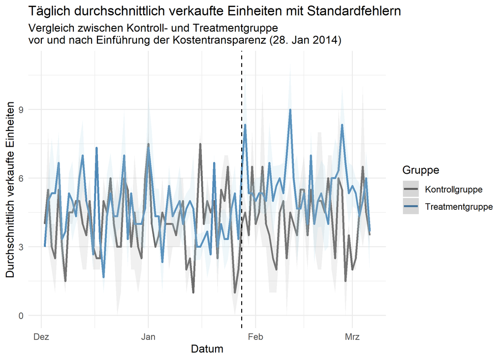

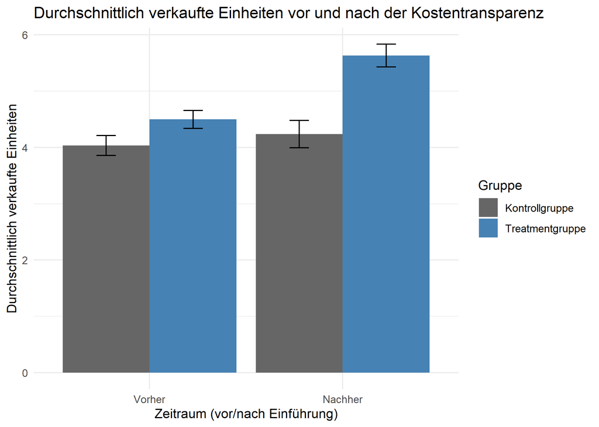

**Beschreibung der Grafiken**  
In der ersten Grafik sind die durchschnittlichen verkauften Einheiten auf täglicher Basis zu sehen. Unterschieden wird wieder in Kontrollgruppe (grau) und Treatmentgruppe (blau). Auf der x-Achse ist die Zeit abgetragen und auf der y-Achse die durchschnittlichen verkauften Einheiten. Der Stichtag, an dem die Kostentransparenz eingeführt wurde ist wieder durch die gestrichelte Linie gekennzeichnet.  
Die zweite Grafik zeigt auch die durchschnittlichen verkauften Einheiten vor und nach Einführung der Kostentransparenz, diesmal aber mithilfe eines Balkendiagramms dargestellt. Zusätzlich wurden die Standardfehler eingefügt. Unterschieden wird auch hier in Treatment- und Kontrollgruppe.

22. In der vorherigen Aufgabe haben Sie den Effekt von Kostentransparenz auf die Verkaufszahlen anhand eines deskriptiven Vergleichs untersucht. Dabei haben Sie die durchschnittlich täglich verkauften Einheiten je Treatment vor und nach der Einführung der Transparenzmaßnahme grafisch gegenübergestellt. In dieser Aufgabe sollen Sie diesen Effekt nun ökonometrisch genauer untersuchen, indem Sie den Difference-in-Differences Ansatz in einem Regressionsrahmen anwenden.

Untersuchen Sie den Effekt der Einführung von Kostentransparenz auf die Verkaufszahlen mithilfe einer Difference-in-Differences Regression. Verwenden Sie hierfür Beobachtungen an Werktagen, sowie am Wochenende (Montag bis Sonntag), mit positiven Verkaufszahlen.

Erstellen Sie insgesamt zwei Regressionsmodelle:

- Basismodell ohne Kontrollvariablen
- Modell mit Kontrolle für Wochentagseffekte

Stellen Sie die Ergebnisse anschaulich dar. Beschreiben und interpretieren Sie Ihre Ergebnisse. Gehen Sie insbesondere auf folgende Aspekte ein.

- Wie würden Sie die Größe des Effekts interpretieren, den Sie für `treated:post` erhalten haben?
- Welche Vorteile bringt es, log_units (logarithmierte Verkäufe) als abhängige Variable zu verwenden?
- Können Sie aus Ihrer Schätzung auf einen kausalen Effekt der Kostentransparenz schließen?
- Inwiefern hilft die Kontrolle für Wochentage dabei, Verzerrungen in der Schätzung zu vermeiden?
- Würden Sie auf Basis Ihrer Analyse eine Empfehlung zur Beibehaltung oder Ausweitung der Kostentransparenz geben?
- Worin könnten ihrer Ansicht nach Probleme liegen bei der Betrachtung eines natürlichen Experiments, die die Ergebnisse verzerren könnten?

*Hinweis 1:* Nutzen Sie für die Schätzung die `feols()`-Funktion aus dem fixest-Paket.

*Hinweis 2:* Nutzen Sie die logarithmierten täglichen Verkaufszahlen als abhängige Variable.

|  | *abhängige Variable:* | log. tägliche Verkaufszahlen |
| --- | --- | --- |
| Treatment-Gruppe | 0.078+ | 0.079+ |
|  | (0.047) | (0.047) |
| Nach Intervention | 0.047 | 0.046 |
|  | (0.058) | (0.058) |
| DiD (Treatment × Post) | 0.150* | 0.150* |
|  | (0.075) | (0.075) |
| Num.Obs. | 470 | 470 |
| R2 | 0.065 | 0.086 |
| R2 Adj. | 0.059 | 0.068 |
| Std.Errors | IID | IID |

+ p < 0.1, * p < 0.05, ** p < 0.01, *** p < 0.001

**Beschreibung der Regressionsanalyse**  
In der Regressionstabelle sind zwei Regressionen zu erkennen. Einmal wurde diese ohne Kontrollvariablen durchgeführt und einmal mit.

**Welche Vorteile bringt es, logarithmierte Verkäufe als abhängige Variable zu verwenden?**  
Eine logarithmierung der Verkaufszahlen hilft eine symmetrische Verteilung zu erhalten. Große Ausreißer, z.B. wenn an einem Tag sehr viel verkauft wurde, werden dadurch abgeschwächt. Außerdem lässt die Logarithmierung eine prozentuale Interpretation der Effekte zu, was intuitiver ist.

**Ist ein kausaler Effekt ableitbar?**  
Wenn bestimmte Bedingungen erfüllt sind ist eine kausale Aussage möglich. Zum einen muss die Paralleltrend-Annahme erfüllt sein, d.h., Verkaufszahlen beider Gruppen wären ohne Intervention gleich verlaufen. Außerdem darf es keine anderen gleichzeitigen Einflüsse geben, die nur die Treatmentgruppe betreffen. Da es sich hier um ein natürliches Experiment handelt, ist ein kausaler Effekt plausibel, wenn externe Störfaktoren ausgeschlossen werden.

**Inwiefern hilft die Kontrolle für Wochentage dabei, Verzerrungen in der Schätzung zu vermeiden?**  
Verkaufszahlen variieren typischerweise stark je nach Wochentag (z.B. mehr Verkäufe am Wochenende). Die Einbeziehung der Wochentage hilft, systematische Schwankungen herauszurechnen, die nicht durch die Transparenzmaßnahme verursacht wurden. Dadurch wird der DiD-Effekt präziser geschätzt.

**Empfehlung zur Beibehaltung oder Ausweitung?**  
Auf Basis der Ergenisse ist eine Beibehaltung der Kostentransparenz aufjedenfall sinnvoll, da hier ein signifikanter Effekt besteht, der eine ökonomisch sinnvolle Größenordnung hat. Weitere Analysen, z.B. über längere Zeiträume oder mit Segmentierung nach Kundengruppen, könnten zusätzliche Erkenntnisse liefern.

**Potenzielle Verzerrungsquellen bei natürlichen Experimenten**  
Wenn die Paralleltrend-Annahme nicht erfüllt ist, da es unterschiedliche Entwicklung schon vor dem Cutoff gab, könnte dies zu einer erheblichen Verzerrung führen. Außerdem könnten andere externe Einflüsse wie z.B. Preisänderungen, Marketingaktionen oder Feiertage, die nicht kontrolliert wurden das natürliche Experiment beeinflussen. Auch Selektionseffekte, die beispielsweise bestimmte Kundengruppen gezielt der Treatment-Gruppe zugewiesen haben, können bei natürlichen Experimenten nicht immer ausgeschlossen werden.

# Literatur

Mohan, B., Buell, R. W., & John, L. K. (2020). Lifting the veil: The benefits of cost transparency. Marketing Science, 39(6), 1105-1121. https://doi.org/10.1287/mksc.2019.1200

# Anhang

## Mediator

Im Rahmen von Mediationen ist der Mediator eine Variable, die den erklärenden Zusammenhang zwischen einer unabhängigen und einer abhängigen Variable vermittelt. Dabei wird untersucht, inwieweit der Einfluss der unabhängigen Variablen (z.B. Kostentransparenz) auf die abhängige Variable (z.B. Kaufabsicht) über einen vermittelnden Mechanismus - wie das Vertrauen der Kunden - erfolgt.

1. **Mediatoreffekt**: Der Mediatoren-Effekt, oft als ACME (Average Causal Mediation Effect) bezeichnet, beschreibt den indirekten Effekt, den die unabhängige Variable auf die abhängige Variable über den Mediator ausübt. Ist dieser Effekt signifikant, signalisiert dies, dass ein wesentlicher Teil des gesamten Einflusses über den vermittelnden Mechanismus läuft. Gleichzeitig kann ein nicht-signifikanter direkter Effekt (ADE - Average Direct Effect) darauf hindeuten, dass der Mediator den hauptsächlichen Erklärungsmechanismus darstellt.
2. **Funktion und Wirkung des Mediators**: Analog zum Konzept der signalgebenden Funktion bei Statussymbolen - deren Wert unter anderem von der Exklusivität und dem sozialen Kontext abhängt - fungiert der Mediator als vermittelnder Kanal, der erklärt, wie und warum der ursprüngliche Zusammenhang zwischen zwei Variablen zustande kommt. Der Mediator „überträgt“ quasi den Effekt der unabhängigen Variable auf die abhängige Variable. Dadurch kann in Modellen, in denen der direkte Zusammenhang zwischen der unabhängigen und der abhängigen Variable durch die Einbeziehung des Mediators verschwindet oder abgeschwächt wird, abgeleitet werden, dass der Mechanismus über den Mediator läuft. Dies ermöglicht ein tieferes Verständnis der zugrundeliegenden psychologischen Prozesse - etwa wie das Vertrauen der Kunden die Wirkung von Kostentransparenz auf deren Kaufabsicht vermittelt.

Zusammengefasst spielt der Mediator eine zentrale Rolle bei der Aufklärung der kausalen Mechanismen, indem er als vermittelnder Faktor zwischen Ursache und Wirkung identifiziert wird. Die signifikante Vermittlung über den Mediator zeigt, dass nicht allein das Vorhandensein von Kostentransparenz entscheidend ist, sondern auch, inwiefern diese Transparenz das Vertrauen stärkt - was wiederum maßgeblich die Kaufabsicht beeinflusst. So liefert die Mediationsanalyse wertvolle Einsichten, die über einfache bivariate Zusammenhänge hinausgehen und die Komplexität kausaler Mechanismen innerhalb von sozialen oder marktorientierten Prozessen sichtbar machen.